# MLB 2025 Batting Lineup: Data Preparation

Math 534 Project

2026-10-29

# 1 Project Entry Point and Current Scope

This Rmd is the single analysis entry point for the project. All subsequent lineup classification, exploratory analysis, statistical tests, and simulations will be added here rather than maintained in separate analysis scripts. The current version provides reproducible preprocessing of the three source datasets. Final lineup labels and between-group tests have not yet been produced. All prose, comments, and messages in this document must remain in English.

**Key finding for scope review:** applying the scope’s Traditional and OPS-ranked rules exactly as written to the confirmed 2025 sample produces an empty Traditional group and a single OPS-ranked game, so the planned two-group comparison cannot be run as specified. The section *Strict Application of the Scope’s Classification Rules* near the end reports the counts, tests alternative readings, and explains the cause.

The confirmed primary sample uses 2025 outcomes and 2024 official player metrics. All nine starters must have at least 100 PA in 2024, with the same threshold applied to all five teams. Only innings 1-9 and complete half-innings before the first batting-roster substitution are eligible. Missing player metrics are not imputed. Earlier multi-season tables below document source auditing; they are not pooled into the primary sample. The final single-season section and its exports are the handoff for classification.

The original Excel files remain unchanged. Each Knit reads the source files from this directory, writes derived data to `processed/`, and writes quality checks to `quality/`. Derived files with the same names are regenerated on each run. Original fields, Excel row numbers, correction provenance, and issue flags are retained. Unverified information is not imputed by guesswork.

Open this file in RStudio and click **Knit**, or run the following command from the folder that contains this file:

```r
rmarkdown::render("MLB_Lineup_Analysis.Rmd")
```

```r
required <- c("readxl", "dplyr", "tidyr", "stringi", "jsonlite", "knitr", "rmarkdown")
missing_packages <- required[!vapply(required, requireNamespace, logical(1), quietly = TRUE)]
if (length(missing_packages)) stop("Install the following packages first: ", paste(missing_packages, collapse = ", "))
library(dplyr)
library(tidyr)
knitr::opts_chunk$set(echo = TRUE, message = FALSE, warning = TRUE)
# Knit uses the directory containing this Rmd, without machine-specific absolute paths.
dir.create("processed", showWarnings = FALSE)
dir.create("quality", showWarnings = FALSE)
files <- c(stats = "Math 534 Baseball Project-2.xlsx",
           probabilities = "MLB_2023_2026_5Teams_Player_Probabilities.xlsx",
           pbp = "MLB_2023_2026_5Teams_PlayByPlay.xlsx")
stopifnot(all(file.exists(files)))
teams <- c("Dodgers", "Cubs", "Cardinals", "Angels", "Giants")
clean_names <- function(x) {
  x <- tolower(gsub("[^A-Za-z0-9]+", "_", x))
  gsub("^_|_$", "", x)
}
name_key <- function(x) {
  # Generate candidate identity keys; verify uniqueness separately without automatic fuzzy matching.
  tolower(gsub("[^A-Za-z0-9]", "", stringi::stri_trans_general(x, "Latin-ASCII")))
}
normalize_id <- function(x) {
  # Excel stores some integer IDs as strings ending in .0; never round arbitrary IDs.
  x <- trimws(as.character(x))
  sub("^([0-9]+)\\.0+$", "\\1", x)
}
read_source <- function(path) {
  # State columns are empty for the first three seasons, so default guessing can infer logical types.
  # Explicit types prevent two outs from becoming TRUE and base-state text from becoming NA.
  types <- switch(path,
    "Math 534 Baseball Project-2.xlsx" = c("text", "numeric", "text", rep("numeric", 18)),
    "MLB_2023_2026_5Teams_Player_Probabilities.xlsx" = c("text", "numeric", "text", "text", rep("numeric", 10)),
    "MLB_2023_2026_5Teams_PlayByPlay.xlsx" = c("text", "numeric", "date", "text", "numeric", "text",
      "numeric", "text", "text", "text", "numeric", "numeric", "text", "numeric", "text", "text", "numeric"))
  x <- readxl::read_excel(path, col_types = types, .name_repair = "minimal")
  names(x) <- clean_names(names(x))
  x$source_row <- seq_len(nrow(x)) + 1L
  fields <- setdiff(names(x), "source_row")
  empty <- rowSums(!is.na(x[fields])) == 0
  attr(x, "blank_rows") <- sum(empty)
  x <- x[!empty, ]
  x <- x %>% mutate(across(where(is.character), ~na_if(trimws(.x), "")))
  x
}
write_csv <- function(x, path) {
  write.csv(as.data.frame(x), path, row.names = FALSE, na = "", fileEncoding = "UTF-8")
}
stats_raw <- read_source(files[["stats"]])
prob_raw <- read_source(files[["probabilities"]])
pbp_raw <- read_source(files[["pbp"]])
source_manifest <- tibble(source = names(files), file = unname(files),
                         md5 = unname(tools::md5sum(files)),
                         nonempty_rows = c(nrow(stats_raw), nrow(prob_raw), nrow(pbp_raw)))
knitr::kable(source_manifest)
```

| source | file | md5 | nonempty_rows |
| --- | --- | --- | --- |
| stats | Math 534 Baseball Project-2.xlsx | 447c2461f372b688f1ba77a3a85f45e8 | 212 |
| probabilities | MLB_2023_2026_5Teams_Player_Probabilities.xlsx | ec3482861f98669763477b244540a63d | 511 |
| pbp | MLB_2023_2026_5Teams_PlayByPlay.xlsx | a78a9b7fe728297f417a8d3de30ef89b | 121588 |

# 2 Confirmed Decisions and Official Source Supplement

The user confirmed actual nine-player game lineups, verified MLB supplementation, previous complete-season official metrics, and complete half-innings before the first batting-roster substitution. On 2026-10-29, the user confirmed 2025 outcomes, 2024 metrics, and innings 1-9 only. After reviewing team coverage, the user revised the prior-season threshold from 150 to 100 PA for every starter on every team, retaining all five teams. Fixed rosters are reserved for simulation. No lineup labels are assigned here.

Official responses are cached locally so subsequent rendering does not repeatedly download games. The cache preserves the source URL and retrieval timestamp. Failed requests remain explicit failures. Official values are used only after the game ID, date, team, and batting half agree with the supplied record. These are independently retrieved records, although the original workbook may itself originate from the same MLB provider.

```r
dir.create("source_cache", showWarnings = FALSE)
dir.create("source_cache/mlb_games", showWarnings = FALSE)
scalar <- function(x, default = NA_character_) if (is.null(x) || !length(x)) default else as.character(x[[1]])
num <- function(x) suppressWarnings(as.numeric(scalar(x)))
cache_json <- function(url, path) {
  if (file.exists(path)) {
    old <- tryCatch(readRDS(path), error = function(e) NULL)
    if (!is.null(old) && identical(old$url, url) && !is.null(old$data)) return(old)
  }
  answer <- tryCatch({
    old_timeout <- getOption("timeout"); options(timeout = 30)
    on.exit(options(timeout = old_timeout), add = TRUE)
    data <- jsonlite::fromJSON(url, simplifyVector = FALSE)
    if (!is.null(data$messageNumber)) stop(scalar(data$message))
    list(url = url, retrieved_at_utc = format(Sys.time(), tz = "UTC", usetz = TRUE), data = data, error = NA_character_)
  }, error = function(e) list(url = url, retrieved_at_utc = format(Sys.time(), tz = "UTC", usetz = TRUE),
                             data = NULL, error = conditionMessage(e)))
  if (!is.null(answer$data)) {
    tmp <- paste0(path, ".tmp"); saveRDS(answer, tmp); file.rename(tmp, path)
  }
  answer
}
team_ids <- c(Dodgers = "119", Cubs = "112", Cardinals = "138", Angels = "108", Giants = "137")
feed_fields <- paste(c("gamePk", "gameData", "datetime", "officialDate", "status", "abstractGameState",
  "teams", "id", "name", "liveData", "boxscore", "players", "person", "fullName", "battingOrder",
  "stats", "batting", "linescore", "innings", "num", "home", "away", "runs", "plays", "allPlays",
  "atBatIndex", "about", "inning", "halfInning", "isComplete", "matchup", "batter", "result", "event",
  "eventType", "awayScore", "homeScore", "count", "outs", "playEvents", "isSubstitution", "details",
  "player", "position", "code", "runners", "movement", "start", "end", "isOut", "runner"), collapse = ",")
game_ids <- sort(unique(normalize_id(pbp_raw$game_id)))
fetch_game <- function(g) {
  u <- paste0("https://statsapi.mlb.com/api/v1.1/game/", g, "/feed/live?fields=", feed_fields)
  a <- cache_json(u, file.path("source_cache/mlb_games", paste0(g, ".rds")))
  tibble(game_id = g, url = u, retrieved_at_utc = a$retrieved_at_utc,
         download_ok = !is.null(a$data), error = a$error)
}
# Socket workers avoid macOS network-library failures after fork. Each game has its own cache file.
workers <- 4L
cluster <- parallel::makePSOCKcluster(workers)
official_downloads <- tryCatch({
  parallel::clusterCall(cluster, setwd, getwd())
  parallel::clusterEvalQ(cluster, suppressPackageStartupMessages(library(dplyr)))
  parallel::clusterExport(cluster, c("scalar", "cache_json", "fetch_game", "feed_fields"), envir = environment())
  bind_rows(parallel::parLapply(cluster, game_ids, fetch_game))
}, finally = parallel::stopCluster(cluster))
knitr::kable(count(official_downloads, download_ok))
```

| download_ok | n |
| --- | --- |
| TRUE | 2978 |

```r
parse_game <- function(g) {
  path <- file.path("source_cache/mlb_games", paste0(g, ".rds"))
  if (!file.exists(path)) return(NULL)
  saved_game <- readRDS(path); z <- saved_game$data
  if (scalar(z$gamePk) != g) stop("Cached game identity mismatch: ", g)
  date <- as.Date(scalar(z$gameData$datetime$officialDate))
  meta <- starts <- batters <- halves <- plays <- changes <- list()
  for (side in c("away", "home")) {
    tid <- scalar(z$gameData$teams[[side]]$id)
    team <- names(team_ids)[match(tid, team_ids)]
    if (is.na(team)) next
    half <- if (side == "away") "top" else "bottom"
    meta[[side]] <- tibble(team = team, game_id = g, official_date = date, official_half = half,
      official_state = scalar(z$gameData$status$abstractGameState),
      official_game_runs = num(z$liveData$linescore$teams[[side]]$runs))
    players <- z$liveData$boxscore$teams[[side]]$players
    b <- bind_rows(lapply(players, function(p) {
      order <- num(p$battingOrder)
      if (is.na(order)) return(NULL)
      tibble(team = team, game_id = g, batter_id = scalar(p$person$id),
        official_name = scalar(p$person$fullName), order_code = as.integer(order),
        slot = as.integer(order %/% 100), entry_sequence = as.integer(order %% 100))
    }))
    batters[[side]] <- b
    starts[[side]] <- b %>% filter(entry_sequence == 0L)
    halves[[side]] <- bind_rows(lapply(z$liveData$linescore$innings, function(i) {
      r <- num(i[[side]]$runs)
      # Missing runs for a home ninth that was never played is not a zero-run half-inning.
      if (is.na(r)) return(NULL)
      tibble(team = team, game_id = g, inning = as.integer(num(i$num)), inning_half = half, official_inning_runs = r)
    }))
  }
  all_batters <- bind_rows(batters)
  for (p in z$liveData$plays$allPlays) {
    half <- scalar(p$about$halfInning); side <- if (half == "top") "away" else "home"
    tid <- scalar(z$gameData$teams[[side]]$id); team <- names(team_ids)[match(tid, team_ids)]
    index <- as.integer(num(p$atBatIndex)); inning <- as.integer(num(p$about$inning))
    if (!is.na(team)) {
      rr <- p$runners
      runner_out_only <- length(rr) > 0 && all(vapply(rr, function(r) {
        !is.null(r$movement$start) && isTRUE(r$movement$isOut) &&
          scalar(r$details$runner$id) != scalar(p$matchup$batter$id)
      }, logical(1)))
      plays[[length(plays) + 1L]] <- tibble(team = team, game_id = g, play_index = index, inning = inning,
        inning_half = half, official_batter_id = scalar(p$matchup$batter$id),
        official_event = scalar(p$result$eventType), official_outs_after = num(p$count$outs),
        official_score_after = num(p$result[[paste0(side, "Score")]]),
        official_runner_out_only = runner_out_only)
    }
    for (e in p$playEvents) {
      if (!isTRUE(e$isSubstitution)) next
      id <- scalar(e$player$id)
      # Only substitutions involving a player with an actual batting-order code affect the batting roster.
      candidates <- all_batters %>% filter(batter_id == id, entry_sequence > 0L)
      if (!nrow(candidates)) next
      for (j in seq_len(nrow(candidates))) changes[[length(changes) + 1L]] <- tibble(
        team = candidates$team[j], game_id = g, substitute_id = id, slot = candidates$slot[j],
        substitution_play_index = index, substitution_inning = inning, substitution_half = half,
        substitution_type = scalar(e$details$eventType))
    }
  }
  list(meta = bind_rows(meta), starters = bind_rows(starts), batting_roster = all_batters,
       half_scores = bind_rows(halves), plays = bind_rows(plays), substitutions = bind_rows(changes))
}
parsed_cache_path <- "source_cache/parsed_games.rds"
parse_signature <- paste(deparse(body(parse_game)), collapse = "\n")
game_hashes <- tools::md5sum(file.path("source_cache/mlb_games",
  paste0(official_downloads$game_id[official_downloads$download_ok], ".rds")))
old_parsed <- if (file.exists(parsed_cache_path)) readRDS(parsed_cache_path) else NULL
if (!is.null(old_parsed) && identical(old_parsed$signature, parse_signature) && identical(old_parsed$hashes, game_hashes)) {
  parsed <- old_parsed$data
} else {
  cluster <- parallel::makePSOCKcluster(4L)
  parsed <- tryCatch({
    parallel::clusterCall(cluster, setwd, getwd())
    parallel::clusterEvalQ(cluster, suppressPackageStartupMessages(library(dplyr)))
    parallel::clusterExport(cluster, c("parse_game", "scalar", "num", "team_ids"), envir = environment())
    parallel::parLapply(cluster, official_downloads$game_id[official_downloads$download_ok], parse_game)
  }, finally = parallel::stopCluster(cluster))
  saveRDS(list(signature = parse_signature, hashes = game_hashes, data = parsed), parsed_cache_path)
}
combine_official <- function(name) bind_rows(lapply(parsed, `[[`, name))
official_games <- combine_official("meta")
official_starters <- combine_official("starters")
official_batting_roster <- combine_official("batting_roster")
official_half_scores <- combine_official("half_scores")
official_plays <- combine_official("plays")
official_substitutions <- combine_official("substitutions") %>% distinct()
rm(parsed)
stopifnot(!anyDuplicated(official_games[c("team", "game_id")]),
          !anyDuplicated(official_plays[c("team", "game_id", "play_index")]))
```

```r
dir.create("source_cache/mlb_seasons", showWarnings = FALSE)
fetch_season <- function(year, team = NA_character_) {
  u <- paste0("https://statsapi.mlb.com/api/v1/stats?stats=season&group=hitting&season=", year,
              "&sportIds=1&playerPool=ALL&limit=10000&gameType=R",
              if (!is.na(team)) paste0("&teamId=", team_ids[[team]]) else "")
  path <- file.path("source_cache/mlb_seasons", paste0(year, "_", ifelse(is.na(team), "all", team), ".rds"))
  a <- cache_json(u, path)
  if (is.null(a$data)) stop("Season statistics unavailable: ", u, ": ", a$error)
  s <- a$data$stats[[1]]$splits
  if (!length(s)) stop("Empty season response: ", u)
  bind_rows(lapply(s, function(p) tibble(
    team = team, season = as.integer(scalar(p$season)), batter_id = scalar(p$player$id),
    official_name = scalar(p$player$fullName),
    official_pa = num(p$stat$plateAppearances), official_ab = num(p$stat$atBats),
    official_h = num(p$stat$hits), official_doubles = num(p$stat$doubles),
    official_triples = num(p$stat$triples), official_hr = num(p$stat$homeRuns),
    official_bb = num(p$stat$baseOnBalls), official_hbp = num(p$stat$hitByPitch),
    official_sf = num(p$stat$sacFlies), official_sh = num(p$stat$sacBunts),
    official_so = num(p$stat$strikeOuts), official_obp = num(p$stat$obp),
    official_slg = num(p$stat$slg), official_ops = num(p$stat$ops),
    source_url = u, retrieved_at_utc = a$retrieved_at_utc)))
}
official_previous_seasons <- bind_rows(lapply(2022:2025, fetch_season))
official_team_stats <- bind_rows(lapply(2023:2026, function(y) bind_rows(lapply(teams, function(t) fetch_season(y, t)))))
stopifnot(!anyDuplicated(official_previous_seasons[c("season", "batter_id")]),
          !anyDuplicated(official_team_stats[c("team", "season", "batter_id")]))
knitr::kable(official_team_stats %>% count(team, season, name = "official_player_rows"))
```

| team | season | official_player_rows |
| --- | --- | --- |
| Angels | 2023 | 31 |
| Angels | 2024 | 31 |
| Angels | 2025 | 31 |
| Angels | 2026 | 28 |
| Cardinals | 2023 | 30 |
| Cardinals | 2024 | 26 |
| Cardinals | 2025 | 24 |
| Cardinals | 2026 | 25 |
| Cubs | 2023 | 31 |
| Cubs | 2024 | 25 |
| Cubs | 2025 | 22 |
| Cubs | 2026 | 31 |
| Dodgers | 2023 | 30 |
| Dodgers | 2024 | 22 |
| Dodgers | 2025 | 27 |
| Dodgers | 2026 | 26 |
| Giants | 2023 | 37 |
| Giants | 2024 | 29 |
| Giants | 2025 | 27 |
| Giants | 2026 | 37 |

```r
source_game_dates <- pbp_raw %>% transmute(team, game_id = normalize_id(game_id),
  source_date = as.Date(date)) %>% distinct() %>% left_join(official_games, by = c("team", "game_id"))
date_discrepancies <- source_game_dates %>% filter(source_date != official_date)
dir.create("source_cache/mlb_schedules", showWarnings = FALSE)
schedule_evidence <- bind_rows(lapply(unique(date_discrepancies$game_id), function(g) {
  u <- paste0("https://statsapi.mlb.com/api/v1/schedule?sportId=1&gamePk=", g)
  a <- cache_json(u, file.path("source_cache/mlb_schedules", paste0(g, ".rds")))
  games <- unlist(lapply(a$data$dates, function(d) d$games), recursive = FALSE)
  # A postponed game can appear twice: the old schedule entry and the actual played date.
  candidates <- Filter(function(p) scalar(p$gamePk) == g && !is.null(p$rescheduleGameDate), games)
  if (length(candidates) != 1L) return(tibble(game_id = g, reschedule_verified = FALSE,
    scheduled_utc_date = NA_character_, scheduled_eastern_date = NA_character_, reschedule_date = NA_character_,
    schedule_official_date = NA_character_, schedule_status = NA_character_, schedule_source_url = u))
  p <- candidates[[1]]
  tibble(game_id = g, scheduled_utc_date = substr(scalar(p$gameDate), 1, 10),
    scheduled_eastern_date = format(as.POSIXct(scalar(p$gameDate), format = "%Y-%m-%dT%H:%M:%SZ", tz = "UTC"),
                                    tz = "America/New_York", format = "%Y-%m-%d"),
    reschedule_date = scalar(p$rescheduleGameDate), schedule_official_date = scalar(p$officialDate),
    schedule_status = scalar(p$status$detailedState), schedule_source_url = u,
    reschedule_verified = !is.na(scalar(p$rescheduleGameDate)))
}))
date_corrections <- date_discrepancies %>% left_join(schedule_evidence, by = "game_id") %>% mutate(
  date_correction_verified = coalesce(reschedule_verified & as.character(official_date) == reschedule_date &
    (as.character(source_date) == scheduled_utc_date | as.character(source_date) == scheduled_eastern_date), FALSE))
knitr::kable(date_corrections %>% select(team, game_id, source_date, official_date, date_correction_verified))
```

| team | game_id | source_date | official_date | date_correction_verified |
| --- | --- | --- | --- | --- |
| Dodgers | 745816 | 2024-05-27 | 2024-05-28 | TRUE |
| Cubs | 718700 | 2023-04-05 | 2023-09-01 | TRUE |
| Cubs | 746891 | 2024-04-18 | 2024-04-20 | TRUE |
| Cubs | 745175 | 2024-05-24 | 2024-07-13 | TRUE |
| Cubs | 777459 | 2025-06-18 | 2025-08-18 | TRUE |
| Cubs | 776691 | 2025-08-18 | 2025-08-19 | TRUE |
| Cardinals | 717550 | 2023-06-30 | 2023-07-01 | TRUE |
| Cardinals | 746481 | 2024-04-29 | 2024-04-30 | TRUE |
| Cardinals | 745184 | 2024-05-08 | 2024-08-05 | TRUE |
| Cardinals | 745175 | 2024-05-24 | 2024-07-13 | TRUE |
| Cardinals | 745157 | 2024-06-25 | 2024-06-26 | TRUE |
| Cardinals | 745155 | 2024-07-09 | 2024-07-10 | TRUE |
| Cardinals | 747093 | 2024-07-19 | 2024-07-20 | TRUE |
| Cardinals | 778443 | 2025-04-05 | 2025-04-06 | TRUE |
| Cardinals | 778134 | 2025-04-29 | 2025-04-30 | TRUE |
| Cardinals | 778068 | 2025-05-03 | 2025-05-04 | TRUE |
| Cardinals | 777933 | 2025-05-13 | 2025-05-14 | TRUE |
| Cardinals | 777642 | 2025-06-04 | 2025-06-05 | TRUE |
| Cardinals | 777458 | 2025-06-18 | 2025-06-19 | TRUE |
| Angels | 717247 | 2023-07-26 | 2023-07-27 | TRUE |
| Angels | 716903 | 2023-08-21 | 2023-08-23 | TRUE |
| Angels | 745713 | 2024-08-06 | 2024-08-07 | TRUE |
| Giants | 718558 | 2023-04-16 | 2023-07-24 | TRUE |
| Giants | 716581 | 2023-09-14 | 2023-09-16 | TRUE |

# 3 Preprocessing Principles

- Standardize the types of team, season, batter_id, game_id, and other join fields while retaining source row numbers.
- Remove exact duplicates from derived tables. Quarantine conflicting values under the same key rather than arbitrarily accepting the first record.
- Player statistics summarize full seasons. Passing quality checks **does not make them suitable for pregame classification**. Pregame statistical windows must be established later.
- Define a `minigroup` provisionally as one team’s offensive half-inning, keyed by team, game_id, inning, and inning_half.
- Do not replace missing values with zero, treat every event as a completed plate appearance, or automatically change suspicious season labels.

# 4 Player Identity Mapping

Both the play-by-play and probability datasets contain batter_id. Build a candidate mapping from normalized names to IDs, joining automatically only when a name key maps to one ID within the same team and season. Ambiguous mappings remain unresolved. Normalization handles accents and punctuation but does not constitute official identity verification; retain the mapping for manual review.

```r
pbp_raw <- pbp_raw %>% mutate(team = trimws(team), season = as.integer(season),
                             batter_id = normalize_id(batter_id), game_id = normalize_id(game_id))
prob_raw <- prob_raw %>% mutate(team = trimws(team), season = as.integer(season),
                               batter_id = normalize_id(batter_id))
stats_raw <- stats_raw %>% mutate(team = trimws(team), season = as.integer(season))
identity_evidence <- bind_rows(
  pbp_raw %>% distinct(team, season, player, batter_id) %>% mutate(source = "pbp"),
  prob_raw %>% distinct(team, season, player, batter_id) %>% mutate(source = "probabilities")
) %>% mutate(player_key = name_key(player))
identity_map <- identity_evidence %>% group_by(team, season, player_key) %>%
  summarise(n_ids = n_distinct(batter_id),
            batter_id = if (n_distinct(batter_id) == 1L) first(batter_id) else NA_character_,
            observed_names = paste(sort(unique(player)), collapse = "; "), .groups = "drop")
identity_ambiguities <- identity_map %>% filter(n_ids != 1L)
stats <- stats_raw %>% mutate(player_key = name_key(player)) %>%
  left_join(identity_map, by = c("team", "season", "player_key")) %>%
  mutate(identity_status = case_when(is.na(n_ids) ~ "unmatched", n_ids != 1L ~ "ambiguous",
                                    TRUE ~ "unique_normalized_match"))
stopifnot(nrow(stats) == nrow(stats_raw))
knitr::kable(count(stats, identity_status))
```

| identity_status | n |
| --- | --- |
| unique_normalized_match | 210 |
| unmatched | 2 |

# 5 Dataset 1: Player Statistics

Retain all input records in `player_stats_audited`. Include records in `player_stats_validated` only when identity is unique, conflicts are absent, and required checks pass. Do not fill missing PA from other seasons or incompatible statistical definitions. Independently recalculate SLG from H, 2B, 3B, HR, and AB for validation. HBP and SF, which are needed to verify OBP, are absent from this table, so OBP cannot be fully verified here.

```r
stats <- stats %>% rename(doubles = `2b`, triples = `3b`) %>%
  mutate(singles_calculated = h - doubles - triples - hr,
         total_bases_calculated = h + doubles + 2 * triples + 3 * hr,
         slg_calculated = if_else(ab > 0, total_bases_calculated / ab, NA_real_),
         avg_calculated = if_else(ab > 0, h / ab, NA_real_),
         ops_calculated = obp + slg,
         so_pa_calculated = if_else(pa > 0, so / pa, NA_real_))
# Compare all original numeric fields; exclude source row numbers from exact-duplicate detection.
stat_fields <- c("team", "season", "player_key", "g", "ab", "r", "h", "doubles",
                 "triples", "hr", "rbi", "bb", "so", "sb", "cs", "avg", "obp", "slg", "ops", "pa", "so_pa")
stats$exact_duplicate <- duplicated(as.data.frame(stats[stat_fields]))
versions <- stats %>% filter(!exact_duplicate) %>% count(team, season, player_key, name = "n_versions")
stats <- stats %>% left_join(versions, by = c("team", "season", "player_key")) %>%
  mutate(conflicting_key = n_versions > 1L,
         invalid_pa = is.na(pa) | pa <= 0 | pa < ab,
         invalid_counts = is.na(ab) | ab <= 0 | is.na(h) | h < 0 | h > ab |
           is.na(singles_calculated) | singles_calculated < 0 |
           if_any(all_of(c("g", "doubles", "triples", "hr", "bb", "so")), ~is.na(.x) | .x < 0 | .x %% 1 != 0),
         invalid_rates = is.na(obp) | obp < 0 | obp > 1 | is.na(slg) | slg < 0 | slg > 4 |
           is.na(ops) | ops < 0 | ops > 5 | is.na(avg) | avg < 0 | avg > 1,
         inconsistent_rates = coalesce(abs(slg - slg_calculated) > 0.0011, TRUE) |
           coalesce(abs(avg - avg_calculated) > 0.0011, TRUE) |
           coalesce(abs(ops - ops_calculated) > 0.0021, TRUE),
         metadata_invalid = is.na(team) | !team %in% teams | is.na(season) | !season %in% 2023:2026,
         eligible_season_stats = !exact_duplicate & !conflicting_key & !invalid_pa &
           !invalid_counts & !invalid_rates & !inconsistent_rates & !metadata_invalid &
           identity_status == "unique_normalized_match",
         stats_timing = "full_season_not_pregame")
# Prevent nonunique final join keys when different name keys map to the same player.
id_collisions <- stats %>% filter(eligible_season_stats) %>%
  count(team, season, batter_id) %>% filter(n > 1L)
stats <- stats %>% left_join(id_collisions %>% transmute(team, season, batter_id, id_collision = TRUE),
                            by = c("team", "season", "batter_id")) %>%
  mutate(id_collision = coalesce(id_collision, FALSE),
         eligible_season_stats = eligible_season_stats & !id_collision)
stats_valid <- stats %>% filter(eligible_season_stats)
stats_issues <- stats %>% filter(!eligible_season_stats)
stats_coverage <- stats %>% group_by(team, season) %>%
  summarise(raw_rows = n(), unique_names = n_distinct(player_key),
            validated_rows = sum(eligible_season_stats),
            validated_pa150 = sum(eligible_season_stats & pa >= 150, na.rm = TRUE), .groups = "drop")
knitr::kable(stats_coverage)
```

| team | season | raw_rows | unique_names | validated_rows | validated_pa150 |
| --- | --- | --- | --- | --- | --- |
| Angels | 2023 | 11 | 11 | 11 | 11 |
| Angels | 2024 | 10 | 10 | 10 | 10 |
| Angels | 2025 | 10 | 10 | 10 | 10 |
| Angels | 2026 | 12 | 12 | 12 | 12 |
| Cardinals | 2023 | 12 | 12 | 12 | 12 |
| Cardinals | 2024 | 10 | 10 | 10 | 10 |
| Cardinals | 2025 | 12 | 12 | 12 | 12 |
| Cardinals | 2026 | 10 | 10 | 10 | 10 |
| Cubs | 2023 | 10 | 10 | 10 | 10 |
| Cubs | 2024 | 10 | 10 | 10 | 10 |
| Cubs | 2025 | 10 | 10 | 10 | 10 |
| Cubs | 2026 | 12 | 12 | 12 | 12 |
| Dodgers | 2023 | 11 | 11 | 11 | 11 |
| Dodgers | 2024 | 1 | 1 | 1 | 1 |
| Dodgers | 2025 | 23 | 15 | 4 | 4 |
| Dodgers | 2026 | 11 | 11 | 10 | 10 |
| Giants | 2023 | 12 | 12 | 12 | 12 |
| Giants | 2024 | 5 | 5 | 5 | 5 |
| Giants | 2025 | 10 | 10 | 10 | 10 |
| Giants | 2026 | 10 | 10 | 10 | 10 |

```r
knitr::kable(stats_issues %>% select(source_row, team, season, player, pa, ab,
                                    conflicting_key, invalid_pa, identity_status))
```

| source_row | team | season | player | pa | ab | conflicting_key | invalid_pa | identity_status |
| --- | --- | --- | --- | --- | --- | --- | --- | --- |
| 8 | Dodgers | 2026 | Teoscar Hernandez | NA | 442 | FALSE | TRUE | unique_normalized_match |
| 58 | Dodgers | 2025 | Andy Pages | 624 | 581 | TRUE | FALSE | unique_normalized_match |
| 59 | Dodgers | 2025 | Teoscar Hernández | 546 | 511 | TRUE | FALSE | unique_normalized_match |
| 60 | Dodgers | 2025 | Freddie Freeman | 627 | 556 | TRUE | FALSE | unique_normalized_match |
| 61 | Dodgers | 2025 | Mookie Betts | 663 | 589 | TRUE | FALSE | unique_normalized_match |
| 62 | Dodgers | 2025 | Max Muncy | 388 | 313 | TRUE | FALSE | unique_normalized_match |
| 63 | Dodgers | 2025 | Will Smith | 436 | 362 | TRUE | FALSE | unique_normalized_match |
| 66 | Dodgers | 2025 | Enrique Hernández | 256 | 232 | TRUE | FALSE | unique_normalized_match |
| 67 | Dodgers | 2025 | Miguel Rojas | 317 | 290 | TRUE | FALSE | unique_normalized_match |
| 112 | Dodgers | 2025 | Teoscar Hernández | 546 | 589 | TRUE | TRUE | unique_normalized_match |
| 113 | Dodgers | 2025 | Freddie Freeman | 627 | 542 | TRUE | FALSE | unique_normalized_match |
| 114 | Dodgers | 2025 | Will Smith | 436 | 476 | TRUE | TRUE | unique_normalized_match |
| 115 | Dodgers | 2025 | Mookie Betts | 663 | 450 | TRUE | FALSE | unique_normalized_match |
| 116 | Dodgers | 2025 | Max Muncy | 388 | 237 | TRUE | FALSE | unique_normalized_match |
| 117 | Dodgers | 2025 | Andy Pages | 624 | 403 | TRUE | FALSE | unique_normalized_match |
| 118 | Dodgers | 2025 | Enrique Hernández | 256 | 362 | TRUE | TRUE | unique_normalized_match |
| 119 | Dodgers | 2025 | Gavin Lux | NA | 439 | FALSE | TRUE | unmatched |
| 120 | Dodgers | 2025 | Jason Heyward | NA | 173 | FALSE | TRUE | unmatched |
| 121 | Dodgers | 2025 | Miguel Rojas | 317 | 307 | TRUE | FALSE | unique_normalized_match |
| 122 | Dodgers | 2025 | Chris Taylor | 35 | 213 | FALSE | TRUE | unique_normalized_match |

# 6 Dataset 2: Player Outcome Probabilities

Check the ranges, sums, and key uniqueness of the seven outcome probabilities. Passing these checks establishes numerical consistency, not the correctness of the underlying events or PA denominators.

Preserve the original SLG as `slg_source` and exclude it from usable metrics. Check whether it matches the incorrect formula that divides the weighted sum of hit probabilities by PA again. The probability table does not contain AB, so SLG cannot be independently corrected with confidence. Join `slg_from_validated_stats` only from validated player statistics, leaving unmatched values missing. This joined value still represents a full season.

```r
probs <- prob_raw %>% rename(p_single = single, p_double = double, p_triple = triple,
                            p_home_run = home_run, p_walk_hbp = walk_hbp,
                            p_error_interference = error_interference, p_out = out,
                            slg_source = slg, prob_sum_source = prob_sum)
pcols <- c("p_single", "p_double", "p_triple", "p_home_run", "p_walk_hbp", "p_error_interference", "p_out")
probs$exact_duplicate <- duplicated(as.data.frame(probs[setdiff(names(probs), "source_row")]))
prob_versions <- probs %>% filter(!exact_duplicate) %>% count(team, season, batter_id, name = "n_versions")
probs <- probs %>% left_join(prob_versions, by = c("team", "season", "batter_id")) %>%
  mutate(prob_sum_calculated = rowSums(pick(all_of(pcols))),
         invalid_probability = if_any(all_of(pcols), ~is.na(.x) | .x < 0 | .x > 1),
         invalid_sum = is.na(prob_sum_calculated) | abs(prob_sum_calculated - 1) > 1e-8,
         supplied_sum_mismatch = is.na(prob_sum_source) | abs(prob_sum_calculated - prob_sum_source) > 1e-8,
         invalid_pa = is.na(pa) | pa <= 0 | pa %% 1 != 0,
         conflicting_key = n_versions > 1L,
         weighted_hit_probability = p_single + 2*p_double + 3*p_triple + 4*p_home_run,
         slg_matches_suspect_formula = abs(slg_source - weighted_hit_probability / pa) < 1e-8,
         slg_source_usable = FALSE,
         eligible_probability_vector = !exact_duplicate & !invalid_probability & !invalid_sum &
           !supplied_sum_mismatch & !invalid_pa & !conflicting_key &
           !is.na(team) & team %in% teams & !is.na(season) & season %in% 2023:2026 & !is.na(batter_id)) %>%
  left_join(stats_valid %>% select(team, season, batter_id, slg_from_validated_stats = slg,
                                  obp_from_validated_stats = obp, ops_from_validated_stats = ops,
                                  pa_from_validated_stats = pa),
            by = c("team", "season", "batter_id")) %>%
  mutate(pa_difference_stats = pa - pa_from_validated_stats,
         probability_timing = "full_season_not_pregame")
stopifnot(nrow(probs) == nrow(prob_raw))
knitr::kable(probs %>% summarise(rows = n(), valid_vectors = sum(eligible_probability_vector),
                                suspect_slg_formula_matches = sum(slg_matches_suspect_formula, na.rm = TRUE),
                                validated_slg_available = sum(!is.na(slg_from_validated_stats))))
```

| rows | valid_vectors | suspect_slg_formula_matches | validated_slg_available |
| --- | --- | --- | --- |
| 511 | 511 | 511 | 192 |

# 7 Dataset 3: Play-by-Play Data

## 7.1 Event and Field Standardization

```r
event_aliases <- c(groundout = "field_out", flyout = "field_out", lineout = "field_out",
                   pop_out = "field_out", bunt_groundout = "field_out", bunt_lineout = "field_out",
                   bunt_pop_out = "field_out", forceout = "force_out", grounded_into_dp = "grounded_into_double_play",
                   fielders_choice = "fielders_choice", fielders_choice_out = "fielders_choice_out",
                   catcher_interference = "catcher_interf")
pa_events <- c("field_out", "strikeout", "single", "double", "triple", "home_run", "walk",
               "intent_walk", "hit_by_pitch", "force_out", "grounded_into_double_play", "sac_fly",
               "sac_bunt", "field_error", "fielders_choice", "fielders_choice_out", "double_play",
               "strikeout_double_play", "sac_fly_double_play", "catcher_interf", "triple_play")
non_pa_events <- c("caught_stealing_2b", "caught_stealing_3b", "caught_stealing_home",
                   "pickoff_caught_stealing_2b", "pickoff_caught_stealing_3b", "pickoff_1b",
                   "pickoff_2b", "pickoff_3b", "stolen_base_2b", "stolen_base_3b", "stolen_base_home", "wild_pitch")
pbp <- pbp_raw %>% rename(event_source = event, inning_half_source = inning_half,
                         outs_before_source = outs_before, outs_added_source = outs_added) %>%
  mutate(date = as.Date(date), inning = as.integer(inning), play_index = as.integer(play_index),
         inning_half = tolower(inning_half_source), event_token = clean_names(event_source),
         event = if_else(event_token %in% names(event_aliases), unname(event_aliases[event_token]), event_token),
         completed_pa = case_when(event %in% pa_events ~ TRUE, event %in% non_pa_events ~ FALSE,
                                  TRUE ~ NA),
         runner_format = case_when(grepl("'movement'", runner_movements, fixed = TRUE) ~ "python_literal_nested",
                                   grepl('"runner_id"', runner_movements, fixed = TRUE) ~ "json_flat", TRUE ~ "other"),
         minigroup_id = paste(team, game_id, inning, inning_half, sep = "_"),
         metadata_invalid = is.na(team) | !team %in% teams | is.na(season) | !season %in% 2023:2026 |
           is.na(game_id) | is.na(inning) | inning < 1 | is.na(inning_half) | !inning_half %in% c("top", "bottom") |
           is.na(date) | as.integer(format(date, "%Y")) != season,
         invalid_outs = is.na(outs_after) | outs_after < 0 | outs_after > 3 | outs_after %% 1 != 0,
         invalid_runs = is.na(runs_scored) | runs_scored < 0 | runs_scored %% 1 != 0)
pbp <- pbp %>% left_join(date_corrections %>% select(team, game_id,
  date_corrected_to = official_date, date_correction_verified), by = c("team", "game_id")) %>%
  mutate(date_source = date, date_correction_verified = coalesce(date_correction_verified, FALSE),
         date = if_else(date_correction_verified, date_corrected_to, date))
pbp$exact_duplicate <- duplicated(as.data.frame(pbp[setdiff(names(pbp), "source_row")]))
pbp_versions <- pbp %>% filter(!exact_duplicate) %>% count(team, game_id, play_index, name = "n_versions")
pbp <- pbp %>% left_join(pbp_versions, by = c("team", "game_id", "play_index")) %>%
  mutate(conflicting_key = n_versions > 1L) %>% arrange(team, game_id, play_index)
# Resolve only cases with official identities, runner-only evidence, and the same next-inning batter.
pbp <- pbp %>% left_join(official_games, by = c("team", "game_id")) %>%
  left_join(official_plays %>% select(team, game_id, play_index, official_batter_id,
    official_event, official_outs_after, official_score_after, official_runner_out_only),
    by = c("team", "game_id", "play_index")) %>%
  group_by(team, game_id) %>% arrange(play_index, .by_group = TRUE) %>%
  mutate(next_record_batter_id = lead(batter_id), next_record_inning = lead(inning),
    official_game_identity_verified = coalesce(date == official_date & inning_half == official_half &
      official_state == "Final", FALSE),
    official_play_identity_verified = official_game_identity_verified &
      coalesce(batter_id == official_batter_id & outs_after == official_outs_after, FALSE),
    runner_only_resolution = is.na(completed_pa) & event %in% c("other_out", "runner_out") &
      official_play_identity_verified & coalesce(official_runner_out_only, FALSE) & outs_after == 3 &
      coalesce(next_record_batter_id == batter_id & next_record_inning == inning + 1L, FALSE),
    completed_pa = if_else(runner_only_resolution, FALSE, completed_pa),
    pa_resolution_basis = case_when(runner_only_resolution ~ "official_runner_out_and_same_batter_next_inning",
                                   is.na(completed_pa) ~ "unresolved", TRUE ~ "event_dictionary")) %>% ungroup()
resolved_runner_events <- pbp %>% filter(runner_only_resolution) %>% select(source_row, team, game_id,
  play_index, batter_id, event, official_event, next_record_batter_id, next_record_inning, pa_resolution_basis)
event_dictionary <- pbp %>% count(event_source, event, completed_pa, name = "records")
knitr::kable(event_dictionary)
```

| event_source | event | completed_pa | records |
| --- | --- | --- | --- |
| Bunt Groundout | field_out | TRUE | 25 |
| Bunt Lineout | field_out | TRUE | 1 |
| Bunt Pop Out | field_out | TRUE | 15 |
| Catcher Interference | catcher_interf | TRUE | 10 |
| Double | double | TRUE | 1256 |
| Double Play | double_play | TRUE | 55 |
| Field Error | field_error | TRUE | 181 |
| Fielders Choice | fielders_choice | TRUE | 60 |
| Fielders Choice Out | fielders_choice_out | TRUE | 37 |
| Flyout | field_out | TRUE | 4056 |
| Forceout | force_out | TRUE | 580 |
| Grounded Into DP | grounded_into_double_play | TRUE | 556 |
| Groundout | field_out | TRUE | 4971 |
| Hit By Pitch | hit_by_pitch | TRUE | 399 |
| Home Run | home_run | TRUE | 917 |
| Intent Walk | intent_walk | TRUE | 76 |
| Lineout | field_out | TRUE | 1737 |
| Pop Out | field_out | TRUE | 1421 |
| Runner Out | runner_out | FALSE | 2 |
| Sac Bunt | sac_bunt | TRUE | 104 |
| Sac Fly | sac_fly | TRUE | 215 |
| Sac Fly Double Play | sac_fly_double_play | TRUE | 2 |
| Single | single | TRUE | 4360 |
| Strikeout | strikeout | TRUE | 6724 |
| Strikeout Double Play | strikeout_double_play | TRUE | 15 |
| Triple | triple | TRUE | 100 |
| Walk | walk | TRUE | 2638 |
| catcher_interf | catcher_interf | TRUE | 57 |
| caught_stealing_2b | caught_stealing_2b | FALSE | 116 |
| caught_stealing_3b | caught_stealing_3b | FALSE | 9 |
| caught_stealing_home | caught_stealing_home | FALSE | 13 |
| double | double | TRUE | 3842 |
| double_play | double_play | TRUE | 182 |
| field_error | field_error | TRUE | 504 |
| field_out | field_out | TRUE | 36262 |
| fielders_choice | fielders_choice | TRUE | 192 |
| fielders_choice_out | fielders_choice_out | TRUE | 135 |
| force_out | force_out | TRUE | 1674 |
| grounded_into_double_play | grounded_into_double_play | TRUE | 1537 |
| hit_by_pitch | hit_by_pitch | TRUE | 1046 |
| home_run | home_run | TRUE | 2955 |
| intent_walk | intent_walk | TRUE | 218 |
| other_out | other_out | FALSE | 8 |
| pickoff_1b | pickoff_1b | FALSE | 20 |
| pickoff_2b | pickoff_2b | FALSE | 4 |
| pickoff_3b | pickoff_3b | FALSE | 1 |
| pickoff_caught_stealing_2b | pickoff_caught_stealing_2b | FALSE | 31 |
| pickoff_caught_stealing_3b | pickoff_caught_stealing_3b | FALSE | 2 |
| sac_bunt | sac_bunt | TRUE | 181 |
| sac_fly | sac_fly | TRUE | 660 |
| sac_fly_double_play | sac_fly_double_play | TRUE | 10 |
| single | single | TRUE | 12657 |
| stolen_base_2b | stolen_base_2b | FALSE | 2 |
| strikeout | strikeout | TRUE | 20665 |
| strikeout_double_play | strikeout_double_play | TRUE | 50 |
| triple | triple | TRUE | 321 |
| triple_play | triple_play | TRUE | 2 |
| walk | walk | TRUE | 7717 |
| wild_pitch | wild_pitch | FALSE | 2 |

## 7.2 Out States and Half-Inning Structure

The previous record’s outs_after within the same half-inning provides a candidate value for the current record’s outs_before. A complete half-inning starts with zero outs, but completeness cannot be fully established from these files. Therefore, name the reconstructed field `outs_before_candidate` rather than treating it as verified. Missing base states remain NA. Half-innings ending with fewer than three outs may represent walk-off endings or incomplete records and require box-score verification.

```r
# Retain exact duplicates in the audit table; exclude duplicates and conflicting keys from candidates.
pbp_candidate <- pbp %>% filter(!exact_duplicate, !conflicting_key, !metadata_invalid) %>%
  group_by(team, game_id, inning, inning_half) %>% arrange(play_index, .by_group = TRUE) %>%
  mutate(outs_before_candidate = lag(outs_after, default = 0),
         outs_candidate_basis = if_else(row_number() == 1L, "assume_complete_half_inning_start", "previous_record"),
         outs_added_candidate = outs_after - outs_before_candidate,
         invalid_out_transition = outs_added_candidate < 0 | outs_added_candidate > 3,
         supplied_outs_mismatch = !is.na(outs_before_source) & outs_before_source != outs_before_candidate,
         supplied_added_mismatch = !is.na(outs_added_source) & outs_added_source != outs_added_candidate,
         state_chain_invalid = any(invalid_outs | invalid_out_transition |
                                     supplied_outs_mismatch | supplied_added_mismatch, na.rm = TRUE)) %>% ungroup()
valid_bases <- c("Empty", "1B", "2B", "3B", "1B,2B", "1B,3B", "2B,3B", "1B,2B,3B")
pbp_candidate <- pbp_candidate %>% mutate(
  bases_before_valid_or_missing = is.na(bases_before) | bases_before %in% valid_bases,
  bases_after_valid_or_missing = is.na(bases_after) | bases_after %in% valid_bases)
state_coverage <- pbp_candidate %>% group_by(season) %>%
  summarise(records = n(), missing_outs_before = sum(is.na(outs_before_source)),
            missing_bases_before = sum(is.na(bases_before)), missing_bases_after = sum(is.na(bases_after)),
            missing_outs_added = sum(is.na(outs_added_source)),
            supplied_outs_mismatches = sum(supplied_outs_mismatch),
            supplied_added_mismatches = sum(supplied_added_mismatch), .groups = "drop")
knitr::kable(state_coverage)
```

| season | records | missing_outs_before | missing_bases_before | missing_bases_after | missing_outs_added | supplied_outs_mismatches | supplied_added_mismatches |
| --- | --- | --- | --- | --- | --- | --- | --- |
| 2023 | 30697 | 30697 | 30697 | 30697 | 30697 | 0 | 0 |
| 2024 | 30203 | 30203 | 30203 | 30203 | 30203 | 0 | 0 |
| 2025 | 30175 | 30175 | 30175 | 30175 | 30175 | 0 | 0 |
| 2026 | 30513 | 0 | 0 | 0 | 6180 | 0 | 0 |

## 7.3 Join Coverage and Candidate Minigroup Summaries

Join only unique validated statistical keys, not the original conflicting records. Half-inning runs are candidate sums of runs_scored and still require reconciliation with external game scores. Set every lineup_label to `not_classified`; successful preprocessing does not establish a Traditional or OPS classification.

```r
pbp_joined <- pbp_candidate %>% left_join(
  stats_valid %>% select(team, season, batter_id, season_obp = obp, season_slg = slg, season_ops = ops),
  by = c("team", "season", "batter_id")) %>% mutate(has_validated_season_stats = !is.na(season_ops))
stopifnot(nrow(pbp_joined) == nrow(pbp_candidate))
join_coverage <- pbp_joined %>% group_by(team, season) %>%
  summarise(events = n(), matched = sum(has_validated_season_stats),
            matched_fraction = mean(has_validated_season_stats), .groups = "drop")
unmatched_players <- pbp_joined %>% filter(!has_validated_season_stats) %>%
  count(team, season, batter_id, player, name = "events") %>% arrange(desc(events))
minigroups <- pbp_joined %>% group_by(minigroup_id, team, season, game_id, date, inning, inning_half) %>%
  summarise(n_events = n(), n_known_completed_pa = sum(completed_pa %in% TRUE),
            n_unknown_pa_events = sum(is.na(completed_pa)),
            inning_runs_candidate = if (any(invalid_runs)) NA_real_ else sum(runs_scored),
            end_outs = last(outs_after), first_play_index = first(play_index), last_play_index = last(play_index),
            state_chain_invalid = any(state_chain_invalid),
            all_observed_batters_have_stats = all(has_validated_season_stats), .groups = "drop") %>%
  mutate(end_status = case_when(end_outs == 3 ~ "three_outs_recorded",
                               end_outs < 3 ~ "walkoff_or_incomplete_needs_verification", TRUE ~ "invalid"),
         extra_innings = inning > 9,
         lineup_label = "not_classified", eligible_primary_analysis = FALSE)
knitr::kable(join_coverage, digits = 3)
```

| team | season | events | matched | matched_fraction |
| --- | --- | --- | --- | --- |
| Angels | 2023 | 6085 | 4184 | 0.688 |
| Angels | 2024 | 5924 | 4427 | 0.747 |
| Angels | 2025 | 5929 | 4683 | 0.790 |
| Angels | 2026 | 6010 | 4871 | 0.810 |
| Cardinals | 2023 | 6167 | 5255 | 0.852 |
| Cardinals | 2024 | 6034 | 4746 | 0.787 |
| Cardinals | 2025 | 6000 | 5514 | 0.919 |
| Cardinals | 2026 | 6049 | 4679 | 0.774 |
| Cubs | 2023 | 6167 | 4931 | 0.800 |
| Cubs | 2024 | 6077 | 4878 | 0.803 |
| Cubs | 2025 | 6125 | 5461 | 0.892 |
| Cubs | 2026 | 6290 | 5952 | 0.946 |
| Dodgers | 2023 | 6270 | 5460 | 0.871 |
| Dodgers | 2024 | 6176 | 718 | 0.116 |
| Dodgers | 2025 | 6121 | 1741 | 0.284 |
| Dodgers | 2026 | 6180 | 4669 | 0.756 |
| Giants | 2023 | 6008 | 4756 | 0.792 |
| Giants | 2024 | 5992 | 2441 | 0.407 |
| Giants | 2025 | 6000 | 4573 | 0.762 |
| Giants | 2026 | 5984 | 4252 | 0.711 |

```r
knitr::kable(count(minigroups, end_status))
```

| end_status | n |
| --- | --- |
| three_outs_recorded | 28320 |
| walkoff_or_incomplete_needs_verification | 117 |

# 8 Extended Preprocessing: Coverage, Denominators, and Historical Metrics

This stage reconciles the three local datasets without treating agreement between potentially related sources as independent verification. All newly computed rates describe the events present in the supplied file, not necessarily complete official season totals. No source season labels are changed automatically.

## 8.1 Observed Event Counts and Rate Denominators

Separate completed plate appearances from non-batting events and unknown events. Walks, hit-by-pitches, sacrifices, and catcher interference do not count as at-bats. A sacrifice-fly double play contributes one sacrifice fly. Unknown event types remain unresolved and prevent a player-season from being marked unambiguous. See the MLB definitions of [at-bats](https://www.mlb.com/glossary/standard-stats/at-bat) and [plate appearances](https://www.mlb.com/glossary/standard-stats/plate-appearance).

```r
count_fields <- c("observed_pa", "observed_ab", "observed_h", "observed_doubles", "observed_triples",
                  "observed_hr", "observed_bb", "observed_hbp", "observed_sf", "observed_sh",
                  "observed_ci", "observed_so", "observed_tb", "unknown_events")
event_counts <- pbp_joined %>% mutate(
  observed_pa = as.integer(completed_pa %in% TRUE),
  observed_bb = as.integer(event %in% c("walk", "intent_walk")),
  observed_hbp = as.integer(event == "hit_by_pitch"),
  observed_sf = as.integer(event %in% c("sac_fly", "sac_fly_double_play")),
  observed_sh = as.integer(event == "sac_bunt"), observed_ci = as.integer(event == "catcher_interf"),
  observed_h = as.integer(event %in% c("single", "double", "triple", "home_run")),
  observed_doubles = as.integer(event == "double"), observed_triples = as.integer(event == "triple"),
  observed_hr = as.integer(event == "home_run"),
  observed_so = as.integer(event %in% c("strikeout", "strikeout_double_play")),
  observed_tb = case_when(event == "single" ~ 1L, event == "double" ~ 2L,
                          event == "triple" ~ 3L, event == "home_run" ~ 4L, TRUE ~ 0L),
  observed_ab = observed_pa - observed_bb - observed_hbp - observed_sf - observed_sh - observed_ci,
  unknown_events = as.integer(is.na(completed_pa)))
safe_rate <- function(numerator, denominator) ifelse(denominator > 0, numerator / denominator, NA_real_)
observed_stats <- event_counts %>% group_by(team, season, batter_id) %>%
  summarise(player = first(player), first_observed_date = min(date), last_observed_date = max(date),
            observed_games = n_distinct(game_id), across(all_of(count_fields), sum), .groups = "drop") %>%
  mutate(observed_avg = safe_rate(observed_h, observed_ab),
         observed_slg = safe_rate(observed_tb, observed_ab),
         observed_obp = safe_rate(observed_h + observed_bb + observed_hbp,
                                 observed_ab + observed_bb + observed_hbp + observed_sf),
         observed_ops = observed_obp + observed_slg,
         event_mapping_unambiguous = unknown_events == 0L,
         coverage_status = "supplied_events_only_not_official_season_totals")
stopifnot(all(event_counts$observed_ab %in% 0:1),
          all(observed_stats$observed_pa == with(observed_stats,
            observed_ab + observed_bb + observed_hbp + observed_sf + observed_sh + observed_ci)))
knitr::kable(observed_stats %>% group_by(season) %>% summarise(player_team_rows = n(),
  observed_pa = sum(observed_pa), unknown_events = sum(unknown_events), .groups = "drop"))
```

| season | player_team_rows | observed_pa | unknown_events |
| --- | --- | --- | --- |
| 2023 | 136 | 30631 | 0 |
| 2024 | 124 | 30120 | 0 |
| 2025 | 123 | 30116 | 0 |
| 2026 | 128 | 30511 | 0 |

## 8.2 Reconcile Player Statistics and Probabilities

Compare source counts with the observed event totals. A match is local supporting evidence, not permission to change a season or copy a PA total. Report differences explicitly. Probability reconciliation uses the same seven categories and compares both PA and the category probabilities; unknown events are excluded from the known-PA denominator and separately flagged.

```r
stats_reconciliation <- stats %>% left_join(observed_stats %>% select(-player),
                                            by = c("team", "season", "batter_id")) %>%
  mutate(pa_delta_observed = pa - observed_pa, ab_delta_observed = ab - observed_ab,
         hits_delta_observed = h - observed_h, bb_delta_observed = bb - observed_bb,
         so_delta_observed = so - observed_so,
         count_fingerprint_matches = coalesce(ab == observed_ab & h == observed_h &
           doubles == observed_doubles & triples == observed_triples & hr == observed_hr &
           bb == observed_bb & so == observed_so & unknown_events == 0, FALSE))
event_buckets <- event_counts %>% filter(completed_pa %in% TRUE) %>% mutate(bucket = case_when(
  event == "single" ~ "p_single", event == "double" ~ "p_double", event == "triple" ~ "p_triple",
  event == "home_run" ~ "p_home_run", event %in% c("walk", "intent_walk", "hit_by_pitch") ~ "p_walk_hbp",
  event %in% c("field_error", "catcher_interf") ~ "p_error_interference", TRUE ~ "p_out")) %>%
  count(team, season, batter_id, bucket, name = "observed_count")
prob_reconciliation <- probs %>% select(team, season, batter_id, pa, all_of(pcols)) %>%
  pivot_longer(all_of(pcols), names_to = "bucket", values_to = "source_probability") %>%
  left_join(observed_stats %>% select(team, season, batter_id, observed_pa, unknown_events),
            by = c("team", "season", "batter_id")) %>%
  left_join(event_buckets, by = c("team", "season", "batter_id", "bucket")) %>%
  mutate(observed_count = if_else(!is.na(observed_pa), coalesce(observed_count, 0L), NA_integer_),
         observed_probability = safe_rate(observed_count, observed_pa),
         probability_delta = source_probability - observed_probability,
         pa_delta = pa - observed_pa)
prob_reconciliation_summary <- prob_reconciliation %>% group_by(team, season, batter_id) %>%
  summarise(pa_delta = first(pa_delta), unknown_events = first(unknown_events),
            max_absolute_probability_delta = if (any(is.na(probability_delta))) NA_real_
              else max(abs(probability_delta)), .groups = "drop") %>%
  mutate(matches_observed_events = coalesce(pa_delta == 0 & unknown_events == 0 &
           max_absolute_probability_delta < 1e-8, FALSE))
probs <- probs %>% left_join(prob_reconciliation_summary, by = c("team", "season", "batter_id"))
event_denominators <- event_counts %>% count(team, season, batter_id, name = "all_event_records")
probs <- probs %>% left_join(event_denominators, by = c("team", "season", "batter_id")) %>%
  mutate(source_pa_equals_all_event_records = pa == all_event_records,
         passes_completed_pa_reconciliation = eligible_probability_vector & matches_observed_events)
# Reconstruct a separate seven-category vector with completed PA as the denominator.
# Do not overwrite source probabilities or claim that these are complete-season estimates.
probabilities_observed <- event_buckets %>%
  pivot_wider(names_from = bucket, values_from = observed_count, values_fill = 0) %>%
  left_join(observed_stats %>% select(team, season, batter_id, observed_pa, unknown_events,
                                     observed_slg, observed_obp, observed_ops),
            by = c("team", "season", "batter_id")) %>%
  mutate(across(all_of(pcols), ~safe_rate(.x, observed_pa)),
         probability_sum = rowSums(pick(all_of(pcols))),
         eligible_observed_vector = observed_pa > 0 & unknown_events == 0,
         coverage_status = "completed_PA_in_supplied_events_only",
         timing = "full_observed_season_not_pregame")
stopifnot(all(abs(probabilities_observed$probability_sum - 1) < 1e-8),
          !anyDuplicated(probabilities_observed[c("team", "season", "batter_id")]))
# Candidate cross-season evidence: retain all exact matches, never silently relabel a source row.
fingerprint_candidates <- stats %>% select(source_row, team, source_season = season, player, player_key,
  ab, h, doubles, triples, hr, bb, so) %>% inner_join(
    observed_stats %>% mutate(player_key = name_key(player)) %>%
      filter(event_mapping_unambiguous) %>% select(team, candidate_season = season, player_key, batter_id,
        ab = observed_ab, h = observed_h, doubles = observed_doubles, triples = observed_triples,
        hr = observed_hr, bb = observed_bb, so = observed_so),
    by = c("team", "player_key", "ab", "h", "doubles", "triples", "hr", "bb", "so"),
    relationship = "many-to-many") %>% mutate(season_agrees = source_season == candidate_season,
      disposition = "supporting_evidence_only_source_confirmation_required")
knitr::kable(probs %>% count(season, matches_observed_events))
```

| season | matches_observed_events | n |
| --- | --- | --- |
| 2023 | FALSE | 42 |
| 2023 | TRUE | 94 |
| 2024 | FALSE | 52 |
| 2024 | TRUE | 72 |
| 2025 | FALSE | 36 |
| 2025 | TRUE | 87 |
| 2026 | FALSE | 126 |
| 2026 | TRUE | 2 |

```r
knitr::kable(fingerprint_candidates %>% filter(!season_agrees) %>%
              select(source_row, player, source_season, candidate_season, disposition))
```

| source_row | player | source_season | candidate_season | disposition |
| --- | --- | --- | --- | --- |

In this run, 511 of 511 source PA values equal all event-row counts. Only 255 source vectors pass completed-PA reconciliation. The separate `player_probabilities_observed` table uses completed plate appearances; vectors affected by unknown events remain ineligible. Neither version is a pregame estimate.

## 8.3 Prior-Day Player Metrics Without Same-Day Leakage

Aggregate by batter, season, and calendar date before applying a cumulative lag. Exclude every event on the current date, including both games of a doubleheader. Combine the player’s observed history across the five supplied teams, but do not imply coverage of other teams. Reset at each season; opening-day values remain unavailable. The 150-PA flag in this exploratory table is retained for audit only. It does not control the primary sample, which uses the confirmed 100-PA threshold on previous-season official statistics. Prior unknown events also block this exploratory flag.

```r
daily_counts <- event_counts %>% group_by(batter_id, season, date) %>%
  summarise(across(all_of(count_fields), sum), .groups = "drop") %>%
  arrange(batter_id, season, date) %>% group_by(batter_id, season) %>%
  mutate(across(all_of(count_fields), ~lag(cumsum(.x), default = 0), .names = "prior_{.col}"),
         stats_through_date = lag(date)) %>% ungroup()
pregame_metrics <- daily_counts %>% select(batter_id, season, date, stats_through_date, starts_with("prior_")) %>%
  mutate(prior_obp = safe_rate(prior_observed_h + prior_observed_bb + prior_observed_hbp,
         prior_observed_ab + prior_observed_bb + prior_observed_hbp + prior_observed_sf),
         prior_slg = safe_rate(prior_observed_tb, prior_observed_ab), prior_ops = prior_obp + prior_slg,
         meets_provisional_pa_threshold = prior_observed_pa >= 150 & prior_unknown_events == 0,
         coverage_status = "prior_days_in_supplied_five_team_data_only")
stopifnot(!anyDuplicated(pregame_metrics[c("batter_id", "season", "date")]),
          all(is.na(pregame_metrics$stats_through_date) | pregame_metrics$stats_through_date < pregame_metrics$date))
first_days <- pregame_metrics %>% group_by(batter_id, season) %>% slice_min(date, n = 1) %>% ungroup()
stopifnot(all(first_days$prior_observed_pa == 0), all(is.na(first_days$prior_ops)))
# Independently reconcile the cumulative endpoint against the complete daily totals.
endpoint_check <- daily_counts %>% group_by(batter_id, season) %>% summarise(
  total_pa = sum(observed_pa), endpoint_pa = last(prior_observed_pa) + last(observed_pa), .groups = "drop")
stopifnot(all(endpoint_check$total_pa == endpoint_check$endpoint_pa))
pbp_joined <- pbp_joined %>% left_join(pregame_metrics,
                                      by = c("batter_id", "season", "date"))
stopifnot(nrow(pbp_joined) == nrow(pbp_candidate))
knitr::kable(pregame_metrics %>% group_by(season) %>% summarise(player_dates = n(),
  dates_with_150_prior_pa = sum(meets_provisional_pa_threshold), .groups = "drop"))
```

| season | player_dates | dates_with_150_prior_pa |
| --- | --- | --- |
| 2023 | 8158 | 4281 |
| 2024 | 8025 | 4194 |
| 2025 | 7922 | 4494 |
| 2026 | 8144 | 4271 |

## 8.4 Game Coverage and Remaining Readiness Gates

Internal checks can identify missing inning numbers or inconsistent metadata but cannot prove that all games, extra innings, plays, or substitutions were supplied. Games ending before nine offensive half-innings may be legitimate. Keep these checks as review flags rather than automatic exclusions. External game-score verification and batting-order reconstruction remain separate requirements.

```r
game_coverage <- pbp_joined %>% group_by(team, season, game_id) %>% summarise(
  dates = n_distinct(date), batting_halves = n_distinct(inning_half),
  first_inning = min(inning), last_inning = max(inning), observed_half_innings = n_distinct(inning),
  consecutive_innings_from_one = identical(sort(unique(inning)), seq_len(max(inning))),
  unknown_pa_events = sum(is.na(completed_pa)),
  runs_candidate = if (any(invalid_runs)) NA_real_ else sum(runs_scored),
  .groups = "drop")
minigroup_readiness <- pbp_joined %>% group_by(minigroup_id) %>% summarise(
  all_observed_batters_have_prior_metrics = all(!is.na(prior_ops)),
  all_observed_batters_meet_pa_threshold = all(meets_provisional_pa_threshold), .groups = "drop")
minigroups <- minigroups %>% left_join(minigroup_readiness, by = "minigroup_id")
local_only_readiness <- tibble(
  requirement = c("Typed import and lossless joins", "Observed event count reconciliation",
                  "Prior-day metrics without same-day outcomes", "Complete source season statistics",
                  "Official game-score reconciliation", "Starting order and substitutions"),
  status = c("implemented_and_checked", "implemented_differences_retained", "implemented_with_coverage_limits",
             "unresolved_source_conflicts_and_gaps", "requires_external_verification", "not_yet_reconstructed"))
knitr::kable(game_coverage %>% group_by(season) %>% summarise(team_games = n(),
  games_with_extra_innings_in_file = sum(last_inning > 9),
  games_with_inning_gaps = sum(!consecutive_innings_from_one), .groups = "drop"))
```

| season | team_games | games_with_extra_innings_in_file | games_with_inning_gaps |
| --- | --- | --- | --- |
| 2023 | 810 | 0 | 0 |
| 2024 | 810 | 0 | 0 |
| 2025 | 810 | 0 | 0 |
| 2026 | 810 | 0 | 0 |

```r
knitr::kable(local_only_readiness)
```

| requirement | status |
| --- | --- |
| Typed import and lossless joins | implemented_and_checked |
| Observed event count reconciliation | implemented_differences_retained |
| Prior-day metrics without same-day outcomes | implemented_with_coverage_limits |
| Complete source season statistics | unresolved_source_conflicts_and_gaps |
| Official game-score reconciliation | requires_external_verification |
| Starting order and substitutions | not_yet_reconstructed |

The supplied file contains 0 team-games with an observed inning beyond nine. This is a coverage warning, not evidence that no real games went to extra innings. Source conflicts and missing coverage remain unresolved rather than being filled with observed partial-season totals.

# 9 Verified Inputs for Future Minigroup Classification

This section prepares evidence and candidate inputs only. Previous-season metrics cover all MLB teams for each player ID. They avoid the five-team coverage restriction of the earlier exploratory prior-day table. Source workbook records remain available for audit; the official supplementary table is used for the new preparation layer with the user’s approval.

## 9.1 Source Corrections and Official Names

Compare each source row with official same-team, same-season counts. For unmatched IDs, accept only a unique normalized-name match within that team and season. Do not guess a different year. Preserve both versions and a correction status.

```r
official_name_keys <- official_team_stats %>% mutate(player_key = name_key(official_name)) %>%
  group_by(team, season, player_key) %>% filter(n() == 1L) %>% ungroup() %>%
  select(team, season, player_key, name_matched_id = batter_id)
official_stat_comparison <- stats %>% left_join(official_name_keys, by = c("team", "season", "player_key")) %>%
  mutate(verified_join_id = coalesce(batter_id, name_matched_id)) %>%
  left_join(official_team_stats, by = c("team", "season", "verified_join_id" = "batter_id")) %>%
  mutate(official_match_available = !is.na(official_pa),
    source_count_difference = coalesce(pa != official_pa | ab != official_ab | h != official_h |
      doubles != official_doubles | triples != official_triples | hr != official_hr | bb != official_bb |
      so != official_so, TRUE),
    correction_status = case_when(!official_match_available ~ "no_same_team_season_official_match",
      source_count_difference | conflicting_key ~ "use_official_record_preserve_source_for_audit",
      TRUE ~ "source_counts_agree_with_official"))
stopifnot(nrow(official_stat_comparison) == nrow(stats))
official_identity_issues <- official_stat_comparison %>% filter(!official_match_available)
knitr::kable(count(official_stat_comparison, correction_status))
```

| correction_status | n |
| --- | --- |
| no_same_team_season_official_match | 2 |
| source_counts_agree_with_official | 191 |
| use_official_record_preserve_source_for_audit | 19 |

```r
knitr::kable(official_identity_issues %>% select(source_row, team, season, player, correction_status))
```

| source_row | team | season | player | correction_status |
| --- | --- | --- | --- | --- |
| 119 | Dodgers | 2025 | Gavin Lux | no_same_team_season_official_match |
| 120 | Dodgers | 2025 | Jason Heyward | no_same_team_season_official_match |

## 9.2 Official Lineup, Substitution, and Score Verification

Initial batting-order codes end in 00; later entries have positive entry sequences. Require exactly nine distinct initial players occupying slots 1 through 9. Do not use the final battingOrder array as the starting lineup. Check official substitutions against replacement players in the box score, including pinch runners and defensive substitutions that change the batting roster.

```r
starter_checks <- official_starters %>% group_by(team, game_id) %>% summarise(
  official_starters_valid = n() == 9L & n_distinct(batter_id) == 9L &
    identical(sort(slot), 1:9), .groups = "drop")
substitute_presence <- official_batting_roster %>% filter(entry_sequence > 0L) %>%
  distinct(team, game_id, batter_id) %>% left_join(
    official_substitutions %>% distinct(team, game_id, substitute_id) %>% mutate(action_found = TRUE),
    by = c("team", "game_id", "batter_id" = "substitute_id"))
substitution_checks <- substitute_presence %>% group_by(team, game_id) %>%
  summarise(unlocated_substitutes = sum(is.na(action_found)), .groups = "drop")
first_substitutions <- official_substitutions %>% group_by(team, game_id) %>%
  summarise(first_substitution_play_index = min(substitution_play_index), .groups = "drop")
game_verification <- pbp_joined %>% group_by(team, season, game_id) %>% summarise(
  official_game_identity_verified = all(official_game_identity_verified),
  observed_play_identities_verified = all(official_play_identity_verified), .groups = "drop") %>%
  left_join(starter_checks, by = c("team", "game_id")) %>%
  left_join(substitution_checks, by = c("team", "game_id")) %>%
  left_join(first_substitutions, by = c("team", "game_id")) %>%
  mutate(unlocated_substitutes = coalesce(unlocated_substitutes, 0L))
lineup_inputs <- official_starters %>% left_join(game_verification, by = c("team", "game_id")) %>%
  mutate(metric_season = season - 1L) %>% left_join(
    official_previous_seasons %>% select(-team) %>% rename(metric_season = season,
      metric_name = official_name, metric_source_url = source_url, metric_retrieved_at = retrieved_at_utc),
    by = c("metric_season", "batter_id")) %>%
  mutate(previous_season_metrics_available = !is.na(official_obp) & !is.na(official_slg) & !is.na(official_ops) &
           !is.na(official_ab) & official_ab > 0 & !is.na(official_pa) & official_pa > 0,
         metrics_precede_game_season = metric_season < season)
lineup_metric_coverage <- lineup_inputs %>% group_by(team, season, game_id) %>% summarise(
  n_missing_previous_season_metrics = sum(!previous_season_metrics_available),
  n_previous_pa_below_150 = sum(is.na(official_pa) | official_pa < 150),
  minimum_previous_pa = if (any(is.na(official_pa))) NA_real_ else min(official_pa), .groups = "drop")
half_verification <- pbp_joined %>% group_by(minigroup_id) %>% summarise(
  all_play_identities_verified = all(official_play_identity_verified),
  known_pa_events_only = all(!is.na(completed_pa)), .groups = "drop")
minigroups <- minigroups %>% left_join(official_half_scores, by = c("team", "game_id", "inning", "inning_half")) %>%
  left_join(game_verification, by = c("team", "season", "game_id")) %>%
  left_join(lineup_metric_coverage, by = c("team", "season", "game_id")) %>%
  left_join(half_verification, by = "minigroup_id") %>% mutate(
    inning_runs_match_official = coalesce(inning_runs_candidate == official_inning_runs, FALSE),
    before_first_roster_substitution = unlocated_substitutes == 0L &
      (is.na(first_substitution_play_index) | last_play_index < first_substitution_play_index),
    complete_before_substitution = before_first_roster_substitution & end_outs == 3,
    technical_inputs_verified = coalesce(official_game_identity_verified & official_starters_valid &
      all_play_identities_verified & known_pa_events_only & inning_runs_match_official & !state_chain_invalid, FALSE),
    classification_input_status = "source_audit_layer_not_primary_sample",
    lineup_label = "not_classified", eligible_primary_analysis = FALSE)
threshold_impact <- bind_rows(lapply(c(0L, 50L, 100L, 150L), function(threshold) {
  passes <- lineup_inputs %>% group_by(team, game_id) %>% summarise(
    all_nine_pass = n() == 9L & all(previous_season_metrics_available & official_pa >= threshold), .groups = "drop")
  candidate <- minigroups %>% left_join(passes, by = c("team", "game_id")) %>%
    filter(technical_inputs_verified, complete_before_substitution, all_nine_pass)
  tibble(minimum_previous_season_pa = threshold, eligible_half_innings_if_selected = nrow(candidate),
         eligible_team_games_if_selected = n_distinct(paste(candidate$team, candidate$game_id)))
}))
official_missing_halves <- anti_join(official_half_scores, minigroups,
                                    by = c("team", "game_id", "inning", "inning_half"))
stopifnot(nrow(minigroups) == n_distinct(pbp_joined$minigroup_id),
          !anyDuplicated(lineup_inputs[c("team", "game_id", "slot")]),
          all(lineup_inputs$metrics_precede_game_season))
knitr::kable(threshold_impact)
```

| minimum_previous_season_pa | eligible_half_innings_if_selected | eligible_team_games_if_selected |
| --- | --- | --- |
| 0 | 9327 | 1347 |
| 50 | 5948 | 846 |
| 100 | 3330 | 467 |
| 150 | 2442 | 338 |

```r
knitr::kable(minigroups %>% summarise(half_innings = n(),
  technical_inputs_verified = sum(technical_inputs_verified),
  verified_complete_before_substitution = sum(technical_inputs_verified & complete_before_substitution),
  source_score_disagreements = sum(!inning_runs_match_official)))
```

| half_innings | technical_inputs_verified | verified_complete_before_substitution | source_score_disagreements |
| --- | --- | --- | --- |
| 28437 | 28023 | 22594 | 414 |

## 9.3 Complete Official Event Layer and Decision Impact

The official event layer includes events omitted from the workbook, preserves source-row links where available, and supplies cumulative-score differences for run increments. Missing workbook events are supplemented, not invented. Extra innings remain in this audit table but are excluded from the confirmed primary sample. A line-score entry absent for an abandoned half-inning remains missing rather than becoming zero.

```r
official_events_complete <- official_plays %>% left_join(official_games, by = c("team", "game_id")) %>%
  mutate(season = as.integer(format(official_date, "%Y")),
    completed_pa = case_when(official_event %in% pa_events ~ TRUE,
      official_event %in% non_pa_events ~ FALSE,
      official_event %in% c("other_out", "runner_out") & official_runner_out_only ~ FALSE, TRUE ~ NA),
    minigroup_id = paste(team, game_id, inning, inning_half, sep = "_")) %>%
  group_by(team, game_id) %>% arrange(play_index, .by_group = TRUE) %>%
  mutate(official_runs_increment = official_score_after - lag(official_score_after, default = 0)) %>% ungroup() %>%
  left_join(pbp %>% select(team, game_id, play_index, source_row, source_runs = runs_scored,
                           source_batter_id = batter_id, date_source), by = c("team", "game_id", "play_index")) %>%
  mutate(supplemented_event = is.na(source_row),
         source_batter_agrees = is.na(source_batter_id) | source_batter_id == official_batter_id)
official_minigroups <- official_events_complete %>% group_by(minigroup_id, team, season, game_id,
  official_date, inning, inning_half) %>% summarise(
    first_play_index = min(play_index), last_play_index = max(play_index), n_events = n(),
    n_supplemented_events = sum(supplemented_event), n_completed_pa = sum(completed_pa %in% TRUE),
    known_pa_events_only = all(!is.na(completed_pa)), source_batters_agree = all(source_batter_agrees),
    official_feed_final = all(official_state == "Final"),
    end_outs = last(official_outs_after), calculated_official_runs = sum(official_runs_increment),
    valid_run_increments = all(!is.na(official_runs_increment) & official_runs_increment >= 0), .groups = "drop") %>%
  left_join(official_half_scores, by = c("team", "game_id", "inning", "inning_half")) %>%
  left_join(game_verification %>% select(team, season, game_id, official_game_identity_verified,
    official_starters_valid, unlocated_substitutes, first_substitution_play_index),
    by = c("team", "season", "game_id")) %>%
  left_join(lineup_metric_coverage, by = c("team", "season", "game_id")) %>%
  mutate(official_score_reconciles = coalesce(calculated_official_runs == official_inning_runs, FALSE),
    complete_before_substitution = end_outs == 3 & unlocated_substitutes == 0L &
      (is.na(first_substitution_play_index) | last_play_index < first_substitution_play_index),
    technical_inputs_verified = coalesce(official_game_identity_verified & official_starters_valid &
      source_batters_agree & official_feed_final & known_pa_events_only & valid_run_increments &
      official_score_reconciles, FALSE),
    lineup_label = "not_classified", eligible_primary_analysis = FALSE,
    classification_input_status = "official_audit_layer_not_primary_sample")
threshold_impact <- bind_rows(lapply(c(0L, 50L, 100L, 150L), function(threshold) {
  passes <- lineup_inputs %>% group_by(team, game_id) %>% summarise(
    all_nine_pass = n() == 9L & all(previous_season_metrics_available & official_pa >= threshold), .groups = "drop")
  candidate <- official_minigroups %>% left_join(passes, by = c("team", "game_id")) %>%
    filter(technical_inputs_verified, complete_before_substitution, all_nine_pass)
  bind_rows(lapply(c(FALSE, TRUE), function(include_extras) {
    selected <- candidate %>% filter(include_extras | inning <= 9)
    tibble(minimum_previous_season_pa = threshold, include_extra_innings = include_extras,
      eligible_half_innings_if_selected = nrow(selected),
      eligible_team_games_if_selected = n_distinct(paste(selected$team, selected$game_id)))
  }))
}))
official_game_score_audit <- official_events_complete %>% group_by(team, game_id) %>%
  summarise(event_run_total = sum(official_runs_increment),
            official_game_runs = first(official_game_runs), .groups = "drop") %>%
  mutate(game_score_reconciles = event_run_total == official_game_runs)
stopifnot(!anyDuplicated(official_minigroups$minigroup_id),
  all(official_game_score_audit$game_score_reconciles),
  sum(official_minigroups$n_events) == nrow(official_events_complete))
knitr::kable(threshold_impact)
```

| minimum_previous_season_pa | include_extra_innings | eligible_half_innings_if_selected | eligible_team_games_if_selected |
| --- | --- | --- | --- |
| 0 | FALSE | 9478 | 1347 |
| 0 | TRUE | 9493 | 1347 |
| 50 | FALSE | 6040 | 846 |
| 50 | TRUE | 6053 | 846 |
| 100 | FALSE | 3380 | 467 |
| 100 | TRUE | 3386 | 467 |
| 150 | FALSE | 2482 | 338 |
| 150 | TRUE | 2485 | 338 |

# 10 Confirmed Single-Season Sample

The user confirmed all parameters below on 2026-10-29. Previous-season statistics are predictors, not additional outcome seasons. Multi-season caches remain source audit material. A half-inning is the outcome unit; a team-game starting lineup is the linked predictor unit. The same game may contribute multiple half-innings, so these are not independent experimental replicates.

```r
analysis_year <- 2025L
metric_year <- analysis_year - 1L
minimum_prior_pa <- 100L
include_extra_innings <- FALSE
selection_confirmed <- !is.na(analysis_year) && !is.na(minimum_prior_pa) && !is.na(include_extra_innings)
season_sample_options <- bind_rows(lapply(c(0L, 50L, 100L, 150L), function(threshold) {
  passes <- lineup_inputs %>% group_by(team, game_id) %>% summarise(
    all_nine_pass = n() == 9L & all(previous_season_metrics_available & official_pa >= threshold), .groups = "drop")
  official_minigroups %>% left_join(passes, by = c("team", "game_id")) %>%
    filter(technical_inputs_verified, complete_before_substitution, inning <= 9, all_nine_pass) %>%
    group_by(season) %>% summarise(minimum_previous_season_pa = threshold,
      candidate_half_innings = n(), candidate_team_games = n_distinct(paste(team, game_id)), .groups = "drop")
}))
decision_register <- tibble(
  decision = c("Roster", "Supplementary source", "Player metrics", "Substitution policy",
               "Outcome season", "Previous-season PA threshold", "Extra innings"),
  status = rep("confirmed", 7),
  choice = c("Actual nine-player game roster", "Verified MLB official data",
    "Previous complete season, all MLB teams", "Complete half-innings before first batting-roster substitution",
    "2025 outcomes with 2024 predictors", paste0("Every starter on every team has at least ", minimum_prior_pa,
      " PA; missing metrics are not imputed"),
    "Innings 1-9 only; extra innings retained outside the primary sample"))
knitr::kable(season_sample_options)
```

| season | minimum_previous_season_pa | candidate_half_innings | candidate_team_games |
| --- | --- | --- | --- |
| 2023 | 0 | 1861 | 281 |
| 2024 | 0 | 2701 | 382 |
| 2025 | 0 | 2819 | 386 |
| 2026 | 0 | 2097 | 298 |
| 2023 | 50 | 786 | 120 |
| 2024 | 50 | 1075 | 151 |
| 2025 | 50 | 2255 | 303 |
| 2026 | 50 | 1924 | 272 |
| 2023 | 100 | 339 | 53 |
| 2024 | 100 | 229 | 33 |
| 2025 | 100 | 1573 | 211 |
| 2026 | 100 | 1239 | 170 |
| 2023 | 150 | 322 | 49 |
| 2024 | 150 | 133 | 19 |
| 2025 | 150 | 1231 | 163 |
| 2026 | 150 | 796 | 107 |

```r
knitr::kable(decision_register)
```

| decision | status | choice |
| --- | --- | --- |
| Roster | confirmed | Actual nine-player game roster |
| Supplementary source | confirmed | Verified MLB official data |
| Player metrics | confirmed | Previous complete season, all MLB teams |
| Substitution policy | confirmed | Complete half-innings before first batting-roster substitution |
| Outcome season | confirmed | 2025 outcomes with 2024 predictors |
| Previous-season PA threshold | confirmed | Every starter on every team has at least 100 PA; missing metrics are not imputed |
| Extra innings | confirmed | Innings 1-9 only; extra innings retained outside the primary sample |

```r
stopifnot(selection_confirmed, metric_year < analysis_year)
```

## 10.1 Verify the Batting-Order Cycle

Number completed plate appearances across the entire team-game, without resetting at inning boundaries. Compare the resulting 1-9 cycle with official starters before the first batting-roster substitution. Non-PA events do not advance the slot. This verifies the observed order only; it does not construct Traditional or OPS templates or label their similarity.

```r
order_events <- official_events_complete %>% filter(season == analysis_year) %>%
  group_by(team, game_id) %>% arrange(play_index, .by_group = TRUE) %>%
  mutate(completed_pa_index = cumsum(completed_pa %in% TRUE),
         expected_slot = as.integer((completed_pa_index - 1L) %% 9L + 1L)) %>% ungroup() %>%
  left_join(official_starters %>% select(team, game_id, expected_slot = slot,
                                       expected_starter_id = batter_id),
            by = c("team", "game_id", "expected_slot")) %>%
  left_join(first_substitutions, by = c("team", "game_id")) %>%
  mutate(before_substitution = is.na(first_substitution_play_index) | play_index < first_substitution_play_index,
         order_match = coalesce(official_batter_id == expected_starter_id, FALSE))
batting_order_audit <- order_events %>% filter(before_substitution) %>% group_by(team, game_id) %>%
  summarise(pre_substitution_pa = sum(completed_pa %in% TRUE),
            unknown_pre_substitution_events = sum(is.na(completed_pa)),
            order_mismatches = sum(completed_pa %in% TRUE & !order_match), .groups = "drop") %>%
  mutate(order_cycle_verified = pre_substitution_pa > 0 & unknown_pre_substitution_events == 0 & order_mismatches == 0)
half_start_slots <- order_events %>% filter(completed_pa %in% TRUE) %>%
  group_by(minigroup_id) %>% slice_min(play_index, n = 1, with_ties = FALSE) %>% ungroup() %>%
  transmute(minigroup_id, starting_slot = expected_slot, first_batter_id = official_batter_id)
knitr::kable(batting_order_audit %>% summarise(team_games_checked = n(),
  completed_pa_checked = sum(pre_substitution_pa), mismatches = sum(order_mismatches)))
```

| team_games_checked | completed_pa_checked | mismatches |
| --- | --- | --- |
| 809 | 25416 | 0 |

## 10.2 Apply Confirmed Filters and Record Exclusions

The flow table applies filters sequentially; removal counts must not be added to overlapping independent flags. Every 2025 half-inning remains in the eligibility audit with its first exclusion reason. The ready table contains no lineup-strategy labels. Rate checks use tolerances consistent with MLB’s three-decimal published rates.

```r
metric_checks <- lineup_inputs %>% filter(season == analysis_year) %>% mutate(
  recalculated_slg = safe_rate(official_h + official_doubles + 2 * official_triples + 3 * official_hr, official_ab),
  recalculated_obp = safe_rate(official_h + official_bb + official_hbp,
    official_ab + official_bb + official_hbp + official_sf),
  official_rate_checks_pass = coalesce(abs(official_slg - recalculated_slg) <= 0.00051 &
    abs(official_obp - recalculated_obp) <= 0.00051 &
    abs(official_ops - official_obp - official_slg) <= 0.0011, FALSE))
roster_eligibility <- metric_checks %>% group_by(team, game_id) %>% summarise(
  all_nine_metrics_available = n() == 9L & all(previous_season_metrics_available),
  all_nine_meet_pa_threshold = n() == 9L & all(previous_season_metrics_available & official_pa >= minimum_prior_pa),
  all_nine_rates_verified = n() == 9L & all(official_rate_checks_pass), .groups = "drop")
eligibility_2025 <- official_minigroups %>% filter(season == analysis_year) %>%
  left_join(roster_eligibility, by = c("team", "game_id")) %>%
  left_join(batting_order_audit, by = c("team", "game_id")) %>%
  left_join(half_start_slots, by = "minigroup_id") %>% mutate(
    in_confirmed_innings = include_extra_innings | inning <= 9L,
    meets_primary_conditions = coalesce(in_confirmed_innings & technical_inputs_verified &
      complete_before_substitution & all_nine_metrics_available & all_nine_meet_pa_threshold, FALSE),
    ready_for_classification = meets_primary_conditions & coalesce(order_cycle_verified & all_nine_rates_verified, FALSE),
    exclusion_reason = case_when(!in_confirmed_innings ~ "extra_inning",
      !technical_inputs_verified ~ "technical_verification_failed",
      !complete_before_substitution ~ "incomplete_or_at_or_after_first_substitution",
      !coalesce(all_nine_metrics_available, FALSE) ~ "missing_previous_season_metrics",
      !coalesce(all_nine_meet_pa_threshold, FALSE) ~ paste0("at_least_one_starter_below_", minimum_prior_pa, "_PA"),
      !coalesce(order_cycle_verified & all_nine_rates_verified, FALSE) ~ "order_or_rate_verification_failed",
      TRUE ~ "included"),
    lineup_id = paste(team, game_id, "starting", sep = "_"))
# A new verification failure must be investigated, not silently converted into a sampling rule.
stopifnot(all(eligibility_2025$ready_for_classification[eligibility_2025$meets_primary_conditions]))
flow_flags <- list(
  "All official 2025 half-innings" = rep(TRUE, nrow(eligibility_2025)),
  "Innings 1-9" = eligibility_2025$in_confirmed_innings,
  "Official identities, events, and scores verified" = eligibility_2025$technical_inputs_verified,
  "Complete half-inning before first roster substitution" = eligibility_2025$complete_before_substitution,
  "All nine starters have 2024 metrics" = eligibility_2025$all_nine_metrics_available,
  "All nine starters meet the confirmed prior-season PA threshold" = eligibility_2025$all_nine_meet_pa_threshold,
  "Observed batting order and metric arithmetic verified" = eligibility_2025$order_cycle_verified & eligibility_2025$all_nine_rates_verified)
names(flow_flags)[6] <- paste0("All nine starters have at least ", minimum_prior_pa, " PA in ", metric_year)
keep <- rep(TRUE, nrow(eligibility_2025)); previous_n <- nrow(eligibility_2025)
sample_flow_2025 <- bind_rows(lapply(names(flow_flags), function(step) {
  keep <<- keep & coalesce(flow_flags[[step]], FALSE)
  result <- tibble(step = step, half_innings_remaining = sum(keep), removed_at_step = previous_n - sum(keep),
    team_games_remaining = n_distinct(paste(eligibility_2025$team[keep], eligibility_2025$game_id[keep])))
  previous_n <<- sum(keep)
  result
}))
classification_inputs_2025 <- eligibility_2025 %>% filter(ready_for_classification) %>%
  transmute(minigroup_id, lineup_id, team, season, date = official_date, game_id,
    inning, inning_half, starting_slot, first_batter_id, n_events, n_completed_pa,
    inning_runs = official_inning_runs, end_outs, first_play_index, last_play_index,
    first_substitution_play_index, metric_season = metric_year, minimum_prior_pa = minimum_prior_pa,
    n_supplemented_events, ready_for_classification, lineup_label = "not_classified") %>%
  arrange(date, game_id, team, inning)
selected_lineups <- classification_inputs_2025 %>% distinct(team, game_id, lineup_id)
lineup_inputs_2025 <- metric_checks %>% inner_join(selected_lineups, by = c("team", "game_id")) %>%
  transmute(lineup_id, team, season, game_id, slot, batter_id, player = official_name,
    metric_season, prior_pa = official_pa, prior_ab = official_ab,
    prior_obp = official_obp, prior_slg = official_slg, prior_ops = official_ops,
    official_rate_checks_pass, metric_source_url, metric_retrieved_at,
    game_source_url = paste0("https://statsapi.mlb.com/api/v1.1/game/", game_id, "/feed/live")) %>%
  arrange(team, game_id, slot)
team_sample_2025 <- classification_inputs_2025 %>% group_by(team) %>% summarise(
  half_innings = n(), team_games = n_distinct(game_id), .groups = "drop") %>%
  complete(team = teams, fill = list(half_innings = 0L, team_games = 0L))
team_threshold_options_2025 <- bind_rows(lapply(c(50L, 100L, 150L), function(threshold) {
  passes <- metric_checks %>% group_by(team, game_id) %>% summarise(
    pass = n() == 9L & all(previous_season_metrics_available & official_pa >= threshold), .groups = "drop")
  official_minigroups %>% filter(season == analysis_year, inning <= 9,
    technical_inputs_verified, complete_before_substitution) %>%
    inner_join(passes %>% filter(pass), by = c("team", "game_id")) %>%
    count(team, name = "candidate_half_innings") %>%
    complete(team = teams, fill = list(candidate_half_innings = 0L)) %>%
    mutate(minimum_previous_season_pa = threshold)
}))
empty_sample_teams <- team_sample_2025$team[team_sample_2025$half_innings == 0L]
# The user confirmed the same 100-PA threshold for every team to retain five-team coverage.
scope_coverage_confirmed <- TRUE
decision_register <- bind_rows(decision_register, tibble(
  decision = "Resulting team coverage after confirmed filters", status = "confirmed",
  choice = paste0("Retain all five teams using a uniform ", minimum_prior_pa, "-PA threshold")))
lineup_row_checks <- lineup_inputs_2025 %>% group_by(lineup_id) %>% summarise(
  complete_nine = n() == 9L & n_distinct(batter_id) == 9L & identical(sort(slot), 1:9), .groups = "drop")
stopifnot(nrow(classification_inputs_2025) > 0,
  scope_coverage_confirmed, length(empty_sample_teams) == 0L,
  setequal(classification_inputs_2025$team, teams),
  !anyDuplicated(classification_inputs_2025$minigroup_id), all(lineup_row_checks$complete_nine),
  setequal(classification_inputs_2025$lineup_id, lineup_inputs_2025$lineup_id),
  all(classification_inputs_2025$season == analysis_year), all(lineup_inputs_2025$metric_season == metric_year),
  all(lineup_inputs_2025$prior_pa >= minimum_prior_pa),
  all(classification_inputs_2025$inning <= 9 & classification_inputs_2025$end_outs == 3),
  all(is.na(classification_inputs_2025$first_substitution_play_index) |
    classification_inputs_2025$last_play_index < classification_inputs_2025$first_substitution_play_index),
  all(classification_inputs_2025$lineup_label == "not_classified"),
  tail(sample_flow_2025$half_innings_remaining, 1) == nrow(classification_inputs_2025))
preprocessing_readiness <- tibble(
  requirement = c("User sampling decisions", "2025 games with 2024 predictors", "Actual starting nine and order cycle",
    "Official half-inning and game scores", "Pre-substitution complete half-innings",
    paste0("All nine prior-season PA >= ", minimum_prior_pa),
    "Unique keys and nine-player joins", "All five teams represented", "Classification performed"),
  status = c(rep("passed_for_selected_sample", 8), "not_started_as_requested"))
knitr::kable(sample_flow_2025)
```

| step | half_innings_remaining | removed_at_step | team_games_remaining |
| --- | --- | --- | --- |
| All official 2025 half-innings | 7196 | 0 | 810 |
| Innings 1-9 | 7102 | 94 | 810 |
| Official identities, events, and scores verified | 7102 | 0 | 810 |
| Complete half-inning before first roster substitution | 5863 | 1239 | 808 |
| All nine starters have 2024 metrics | 2819 | 3044 | 386 |
| All nine starters have at least 100 PA in 2024 | 1573 | 1246 | 211 |
| Observed batting order and metric arithmetic verified | 1573 | 0 | 211 |

```r
knitr::kable(team_sample_2025)
```

| team | half_innings | team_games |
| --- | --- | --- |
| Angels | 71 | 13 |
| Cardinals | 432 | 56 |
| Cubs | 115 | 17 |
| Dodgers | 507 | 69 |
| Giants | 448 | 56 |

```r
knitr::kable(team_threshold_options_2025)
```

| team | candidate_half_innings | minimum_previous_season_pa |
| --- | --- | --- |
| Angels | 234 | 50 |
| Cardinals | 649 | 50 |
| Cubs | 272 | 50 |
| Dodgers | 531 | 50 |
| Giants | 569 | 50 |
| Angels | 71 | 100 |
| Cardinals | 432 | 100 |
| Cubs | 115 | 100 |
| Dodgers | 507 | 100 |
| Giants | 448 | 100 |
| Angels | 0 | 150 |
| Cardinals | 432 | 150 |
| Cubs | 115 | 150 |
| Dodgers | 473 | 150 |
| Giants | 211 | 150 |

```r
knitr::kable(preprocessing_readiness)
```

| requirement | status |
| --- | --- |
| User sampling decisions | passed_for_selected_sample |
| 2025 games with 2024 predictors | passed_for_selected_sample |
| Actual starting nine and order cycle | passed_for_selected_sample |
| Official half-inning and game scores | passed_for_selected_sample |
| Pre-substitution complete half-innings | passed_for_selected_sample |
| All nine prior-season PA >= 100 | passed_for_selected_sample |
| Unique keys and nine-player joins | passed_for_selected_sample |
| All five teams represented | passed_for_selected_sample |
| Classification performed | not_started_as_requested |

The prepared sample contains **1573 half-innings**, linked to **211 team-games** and **209 distinct games**. The lineup table contains 1899 player-slot rows. These are classification inputs, not evidence that either strategy performs better. Filtering on all nine players’ previous-season experience restricts the target population to experienced starting lineups.

**Confirmed coverage:** all five teams have eligible half-innings under the uniform 100-PA rule. Other thresholds above are diagnostic comparisons only. The user selected this rule after reviewing the loss of Angels at 150 PA; no team-specific threshold or missing-value imputation is used. Data preparation and scope confirmation are complete.

Use `processed/classification_inputs_2025.csv` together with `processed/lineup_inputs_2025.csv`, joined by lineup_id. The first table contains half-inning identifiers, observed start slots, and verified runs. The second contains the actual nine-player order and 2024 metrics. The export `processed/classification_ready_2025.rds` packages both tables and the confirmed settings. No Traditional/OPS template, label, statistical comparison, or simulation is produced in this version.

# 11 Data Quality Checks and Exports

Checks guard against join expansion, nonunique keys, loss of records, and use of future-season metrics. Historical source issues remain visible in audit exports. The selected 2025 classification inputs use verified official lineups, 2024 metrics, substitution timing, and scores; they do not depend on the conflicting source-statistics rows.

```r
stopifnot(!anyDuplicated(stats_valid[c("team", "season", "batter_id")]),
          !anyDuplicated(minigroups$minigroup_id),
          sum(minigroups$n_events) == nrow(pbp_joined),
          all(minigroups$lineup_label == "not_classified"),
          all(!probs$slg_source_usable))
# Enforce column types, especially for columns with long stretches of missing values across seasons.
stopifnot(is.numeric(pbp_raw$outs_before), is.numeric(pbp_raw$outs_added),
          is.character(pbp_raw$bases_before), is.character(pbp_raw$bases_after))
summary_checks <- tibble(
  metric = c("stats_nonempty_rows", "stats_validated_rows", "stats_conflicting_rows", "stats_invalid_PA_rows",
             "probability_rows", "valid_probability_vectors", "probability_source_SLG_disabled",
             "pbp_rows", "pbp_exact_duplicates", "pbp_conflicting_rows", "pbp_unknown_PA_events",
             "minigroups", "minigroups_end_below_3", "pbp_records_matched_to_validated_stats"),
  value = c(nrow(stats), nrow(stats_valid), sum(stats$conflicting_key), sum(stats$invalid_pa),
            nrow(probs), sum(probs$eligible_probability_vector), sum(!probs$slg_source_usable),
            nrow(pbp), sum(pbp$exact_duplicate), sum(pbp$conflicting_key), sum(is.na(pbp$completed_pa)),
            nrow(minigroups), sum(minigroups$end_outs < 3), sum(pbp_joined$has_validated_season_stats)))
knitr::kable(summary_checks)
```

| metric | value |
| --- | --- |
| stats_nonempty_rows | 212 |
| stats_validated_rows | 192 |
| stats_conflicting_rows | 16 |
| stats_invalid_PA_rows | 7 |
| probability_rows | 511 |
| valid_probability_vectors | 511 |
| probability_source_SLG_disabled | 511 |
| pbp_rows | 121588 |
| pbp_exact_duplicates | 0 |
| pbp_conflicting_rows | 0 |
| pbp_unknown_PA_events | 0 |
| minigroups | 28437 |
| minigroups_end_below_3 | 117 |
| pbp_records_matched_to_validated_stats | 88191 |

```r
outputs <- list(player_stats_audited = stats, player_stats_validated = stats_valid,
                player_probabilities_clean = probs, play_by_play_clean = pbp_joined,
                minigroups_preclassification = minigroups, player_stats_observed = observed_stats,
                player_metrics_prior_day = pregame_metrics,
                player_probabilities_observed = probabilities_observed,
                official_team_stats = official_team_stats, official_previous_seasons = official_previous_seasons,
                official_starting_lineups = official_starters, official_substitutions = official_substitutions,
                lineup_inputs_preclassification = lineup_inputs,
                official_events_complete = official_events_complete,
                official_minigroups_preclassification = official_minigroups,
                classification_inputs_2025 = classification_inputs_2025,
                lineup_inputs_2025 = lineup_inputs_2025)
for (nm in names(outputs)) write_csv(outputs[[nm]], file.path("processed", paste0(nm, ".csv")))
saveRDS(outputs, "processed/preprocessed_data.rds")
classification_bundle <- list(
  settings = list(analysis_year = analysis_year, metric_year = metric_year, minimum_prior_pa = minimum_prior_pa,
    include_extra_innings = include_extra_innings, roster = "actual_starting_nine",
    substitution_policy = "complete_half_innings_before_first_batting_roster_substitution",
    missing_metric_policy = "no_imputation", scope_coverage_confirmed = scope_coverage_confirmed,
    classification_status = "not_started"),
  minigroups = classification_inputs_2025, lineups = lineup_inputs_2025,
  sample_flow = sample_flow_2025, decisions = decision_register)
saveRDS(classification_bundle, "processed/classification_ready_2025.rds")
quality <- list(source_manifest = source_manifest, summary_checks = summary_checks,
                player_identity_map = identity_map, identity_ambiguities = identity_ambiguities,
                player_stats_issues = stats_issues, stats_coverage = stats_coverage,
                probability_issues = probs %>% filter(!eligible_probability_vector | !slg_source_usable),
                event_dictionary = event_dictionary, state_coverage = state_coverage,
                pbp_excluded_records = pbp %>% filter(exact_duplicate | conflicting_key | metadata_invalid),
                pbp_state_issues = pbp_joined %>% filter(state_chain_invalid | invalid_runs |
                  !bases_before_valid_or_missing | !bases_after_valid_or_missing),
                join_coverage = join_coverage, unmatched_players = unmatched_players,
                stats_reconciliation = stats_reconciliation, probability_reconciliation = prob_reconciliation,
                probability_reconciliation_summary = prob_reconciliation_summary,
                season_fingerprint_candidates = fingerprint_candidates,
                game_coverage = game_coverage, preprocessing_readiness = preprocessing_readiness,
                official_downloads = official_downloads, official_stat_comparison = official_stat_comparison,
                official_identity_issues = official_identity_issues, resolved_runner_events = resolved_runner_events,
                game_verification = game_verification, lineup_metric_coverage = lineup_metric_coverage,
                threshold_impact = threshold_impact, official_missing_halves = official_missing_halves,
                official_substitute_presence = substitute_presence, date_corrections = date_corrections,
                official_game_score_audit = official_game_score_audit,
                season_sample_options = season_sample_options, decision_register = decision_register,
                local_only_readiness = local_only_readiness, batting_order_audit_2025 = batting_order_audit,
                eligibility_2025 = eligibility_2025, sample_flow_2025 = sample_flow_2025,
                team_sample_2025 = team_sample_2025,
                team_threshold_options_2025 = team_threshold_options_2025,
                selected_metric_checks_2025 = metric_checks %>% semi_join(selected_lineups, by = c("team", "game_id")))
for (nm in names(quality)) write_csv(quality[[nm]], file.path("quality", paste0(nm, ".csv")))
# Verify exported RDS structure and row counts, and confirm that source files remain unchanged.
saved <- readRDS("processed/preprocessed_data.rds")
stopifnot(identical(vapply(saved, nrow, integer(1)), vapply(outputs, nrow, integer(1))),
          identical(unname(tools::md5sum(files)), source_manifest$md5))
ready_saved <- readRDS("processed/classification_ready_2025.rds")
stopifnot(identical(ready_saved, classification_bundle))
```

# 12 Subsequent Analysis: Continue Updating This File

1. Data preparation for the confirmed five-team 2025 sample is complete. Stop before classification, as requested.
2. The strict application of the scope’s rules later in this document leaves the Traditional group empty. Before any labels are assigned, the project team must decide whether to compare the strategies by simulation or to redefine the observational groups. Do not tune classification rules using inning runs.
3. Follow page 2 of the revised scope to construct the Traditional order: highest OBP, next-highest OBP, highest remaining OPS, highest remaining SLG, and highest remaining OPS. Sort the remaining four hitters by OPS. The OPS strategy reorders only the same first five hitters and leaves the last four unchanged.
4. Preserve both/neither/unknown cases rather than forcing every observation into one of two strategies. Report classification coverage before comparing outcomes.
5. Account for within-game dependence when comparing runs per half-inning by clustering on game_id. Interpret observational comparisons separately from simulations that reorder the same roster.

The selected inputs pass the data checks and retain all five teams under the confirmed scope. Classification has not started. No claim about strategy performance or causal effects has been made.

# 13 Exploratory Estimate of Classification Coverage

This user-requested feasibility calculation does not assign or export formal labels. It uses only player IDs, batting slots, 2024 metrics, and the number of eligible half-innings attached to each lineup. Runs are not used. The strict scenario requires the observed nine-player order to match the scope exactly. All orders permitted by ties in the published metrics are accepted for this diagnostic; this is not a confirmed tie-breaking policy. A separate top-five-only scenario is shown to quantify the effect of relaxing the last-four requirement, not to adopt that relaxation.

```r
estimate_lineup <- function(d) {
  d <- d[order(d$slot), ]
  orders <- function(indices, criteria) {
    if (!length(indices)) return(list(integer()))
    values <- d[[criteria[1]]][indices]
    choices <- indices[values == max(values)]
    unlist(lapply(choices, function(j) lapply(orders(setdiff(indices, j), criteria[-1]),
                                            function(rest) c(j, rest))), recursive = FALSE)
  }
  a <- orders(1:9, c("prior_obp", "prior_obp", "prior_ops", "prior_slg", rep("prior_ops", 5)))
  b <- unlist(lapply(a, function(v) lapply(orders(v[1:5], rep("prior_ops", 5)),
                                          function(top) c(top, v[6:9]))), recursive = FALSE)
  encode <- function(v) paste(d$batter_id[v], collapse = ",")
  a_codes <- unique(vapply(a, encode, character(1)))
  b_codes <- unique(vapply(b, encode, character(1)))
  tibble(lineup_id = d$lineup_id[1], team = d$team[1],
    roster_key = paste(sort(d$batter_id), collapse = ","), observed_order_key = encode(1:9),
    a_exact = encode(1:9) %in% a_codes, b_exact = encode(1:9) %in% b_codes,
    a_top5 = any(vapply(a, function(v) identical(v[1:5], 1:5), logical(1))),
    b_top5 = any(vapply(b, function(v) identical(v[1:5], 1:5), logical(1))),
    a_variants = length(a_codes), b_variants = length(b_codes),
    templates_overlap = length(intersect(a_codes, b_codes)) > 0L)
}
feasibility_checks <- bind_rows(lapply(split(lineup_inputs_2025, lineup_inputs_2025$lineup_id), estimate_lineup))
# Independent sequential validation of the Traditional exact-match test.
direct_a_check <- vapply(split(lineup_inputs_2025, lineup_inputs_2025$lineup_id), function(d) {
  d <- d[order(d$slot), ]
  criteria <- c("prior_obp", "prior_obp", "prior_ops", "prior_slg", rep("prior_ops", 5))
  all(vapply(1:9, function(j) d[[criteria[j]]][j] == max(d[[criteria[j]]][j:9]), logical(1)))
}, logical(1))
stopifnot(identical(unname(direct_a_check), feasibility_checks$a_exact))
feasibility_counts <- bind_rows(lapply(c("exact", "top5"), function(scenario) {
  a <- feasibility_checks[[paste0("a_", scenario)]]
  b <- feasibility_checks[[paste0("b_", scenario)]]
  diagnostic_group <- ifelse(a & b, "Both", ifelse(a, "Traditional only", ifelse(b, "OPS only", "Neither")))
  checks <- feasibility_checks %>% transmute(lineup_id, diagnostic_group)
  game_counts <- checks %>% count(diagnostic_group, name = "team_games")
  half_counts <- classification_inputs_2025 %>% select(lineup_id) %>%
    left_join(checks, by = "lineup_id") %>% count(diagnostic_group, name = "half_innings")
  full_join(game_counts, half_counts, by = "diagnostic_group") %>%
    complete(diagnostic_group = c("Traditional only", "OPS only", "Both", "Neither"),
             fill = list(team_games = 0L, half_innings = 0L)) %>% mutate(scenario = scenario)
}))
combination_inventory <- tibble(
  quantity = c("Eligible half-innings", "Team-game lineups", "Distinct nine-player rosters",
               "Distinct observed nine-player orders", "Team-games with tie-dependent templates",
               "Team-games whose A and B templates overlap"),
  count = c(nrow(classification_inputs_2025), nrow(feasibility_checks),
    n_distinct(feasibility_checks$roster_key), n_distinct(feasibility_checks$observed_order_key),
    sum(feasibility_checks$a_variants > 1 | feasibility_checks$b_variants > 1),
    sum(feasibility_checks$templates_overlap)))
stopifnot(all(feasibility_counts %>% group_by(scenario) %>% summarise(n = sum(half_innings)) %>%
                pull(n) == nrow(classification_inputs_2025)),
          all(classification_inputs_2025$lineup_label == "not_classified"))
knitr::kable(combination_inventory)
```

| quantity | count |
| --- | --- |
| Eligible half-innings | 1573 |
| Team-game lineups | 211 |
| Distinct nine-player rosters | 100 |
| Distinct observed nine-player orders | 156 |
| Team-games with tie-dependent templates | 91 |
| Team-games whose A and B templates overlap | 77 |

```r
knitr::kable(feasibility_counts %>% select(scenario, diagnostic_group, team_games, half_innings))
```

| scenario | diagnostic_group | team_games | half_innings |
| --- | --- | --- | --- |
| exact | Both | 0 | 0 |
| exact | Neither | 210 | 1565 |
| exact | OPS only | 1 | 8 |
| exact | Traditional only | 0 | 0 |
| top5 | Both | 0 | 0 |
| top5 | Neither | 205 | 1529 |
| top5 | OPS only | 6 | 44 |
| top5 | Traditional only | 0 | 0 |

For a fixed roster and a fixed choice of the top five, there are 5! = 120 possible top-five permutations when slots 6-9 remain fixed. That combinatorial count is different from the two strategies in the scope and from the number of actual observed lineups. Strict and top-five-only counts above are conditional feasibility results, not final classifications or evidence of strategy effectiveness.

An empty Traditional group prevents the proposed two-group comparison under these matching assumptions. Accepting all tied-metric permutations already gives exact matching its most permissive interpretation for the published rates. A similarity-based definition would change the classification question and requires user confirmation; it is not implemented here. Template overlap also means that A and B need not be distinct for every roster. The next section verifies this result with an independent implementation and explains it.

# 14 Strict Application of the Scope’s Classification Rules

This section answers one question for scope review: when the classification rules in the project scope are applied exactly as written to the confirmed 2025 sample, how many half-innings fall into each group? It then explains the result. Only batting slots and player metrics are used. Inning runs are never read, so nothing in this section depends on, or reveals, which strategy scores more. No labels are exported.

## 14.1 Rules as Written in the Scope

Page 2 of `Final Project Scope_ MLB Batting Lineup.pdf` defines the two strategies for a given set of nine hitters:

- **Strategy A, Traditional:** slot 1 is the highest OBP; slot 2 is the next-highest OBP; slot 3 is the highest OPS among the remaining hitters; slot 4 is the highest SLG among the remaining hitters; slot 5 is the next-highest OPS; slots 6-9 hold the remaining four hitters in descending OPS.
- **Strategy B, OPS-ranked:** the same five hitters selected for slots 1-5 are reordered from highest to lowest OPS, and slots 6-9 stay identical to Strategy A.

The summary table on page 3 labels Strategy B as “Best to Worst” (highest OPS through fifth-highest OPS). Read literally, that describes all nine hitters in descending OPS, which can differ from page 2 when a high-OBP, low-OPS hitter enters the Traditional top five. Both readings are tested.

A lineup matches a strategy only if all nine observed slots agree with it. Published rates have three decimals, and every order permitted by tied values is accepted, which is the most permissive form of exact matching. The rules are applied to the actual starting nine of each team-game, and every eligible half-inning inherits the label of its game’s starting lineup.

## 14.2 Group Counts

Four scenarios are reported. Scenario 1 is the confirmed design. Scenarios 2-4 each change one assumption to test whether the result depends on it. Scenario 3 uses end-of-season 2025 metrics, which were not available when the lineups were set; it is a sensitivity check only.

```r
rule_metric <- c("obp", "obp", "ops", "slg", rep("ops", 5))
# Slot j follows Strategy A when its batter has the maximal rule metric among slots j..9 (ties accepted).
slot_follows_traditional <- function(d) vapply(1:9, function(j)
  d[[rule_metric[j]]][j] == max(d[[rule_metric[j]]][j:9]), logical(1))
# Page-2 Strategy B: some tie-permitted Traditional top five equals the observed top five,
# the observed top five is in descending OPS, and slots 6-9 are the remaining hitters in descending OPS.
matches_ops_page2 <- function(d) {
  if (any(diff(d$ops[1:5]) > 0) || any(diff(d$ops[6:9]) > 0)) return(FALSE)
  pick_top_five <- function(remaining, step) {
    if (step > 5L) return(TRUE)
    v <- d[[rule_metric[step]]]
    candidates <- intersect(remaining[v[remaining] == max(v[remaining])], 1:5)
    any(vapply(candidates, function(j) pick_top_five(setdiff(remaining, j), step + 1L), logical(1)))
  }
  pick_top_five(1:9, 1L)
}
# Page-3 table read literally: all nine hitters in descending OPS.
matches_ops_page3 <- function(d) all(diff(d$ops) <= 0)
strict_groups <- function(lineups, ops_rule) {
  bind_rows(lapply(split(lineups, lineups$lineup_id), function(d) {
    d <- d[order(d$slot), ]
    tibble(lineup_id = d$lineup_id[1], team = d$team[1],
           traditional = all(slot_follows_traditional(d)), ops_ranked = ops_rule(d))
  })) %>% mutate(group = case_when(traditional & ops_ranked ~ "Both", traditional ~ "Traditional only",
                                   ops_ranked ~ "OPS only", TRUE ~ "Neither"))
}
group_levels <- c("Traditional only", "OPS only", "Both", "Neither")
count_groups <- function(groups, half_innings, scenario) {
  tibble(group = group_levels) %>%
    left_join(count(groups, group, name = "team_games"), by = "group") %>%
    left_join(half_innings %>% inner_join(groups, by = "lineup_id") %>% count(group, name = "half_innings"),
              by = "group") %>%
    mutate(across(c(team_games, half_innings), ~ coalesce(.x, 0L)), scenario = scenario, .before = 1)
}

lineups_2024_metrics <- lineup_inputs_2025 %>%
  transmute(lineup_id, team, slot, batter_id, player, pa = prior_pa, obp = prior_obp, slg = prior_slg, ops = prior_ops)
lineups_2025_metrics <- lineups_2024_metrics %>% select(lineup_id, team, slot, batter_id, player) %>%
  left_join(official_previous_seasons %>% filter(season == analysis_year) %>%
              transmute(batter_id, obp = official_obp, slg = official_slg, ops = official_ops), by = "batter_id")
half_innings_no_pa_threshold <- eligibility_2025 %>%
  filter(in_confirmed_innings, technical_inputs_verified, complete_before_substitution,
         all_nine_metrics_available, order_cycle_verified, all_nine_rates_verified) %>% select(lineup_id)
lineups_no_pa_threshold <- metric_checks %>%
  mutate(lineup_id = paste(team, game_id, "starting", sep = "_")) %>%
  filter(lineup_id %in% half_innings_no_pa_threshold$lineup_id) %>%
  transmute(lineup_id, team, slot, batter_id, player = official_name,
            obp = official_obp, slg = official_slg, ops = official_ops)
stopifnot(!anyNA(lineups_2025_metrics$ops), !anyNA(lineups_no_pa_threshold$ops),
          all(table(lineups_no_pa_threshold$lineup_id) == 9L))

strict_confirmed <- strict_groups(lineups_2024_metrics, matches_ops_page2)
strict_page3 <- strict_groups(lineups_2024_metrics, matches_ops_page3)
strict_same_season <- strict_groups(lineups_2025_metrics, matches_ops_page2)
strict_no_pa_threshold <- strict_groups(lineups_no_pa_threshold, matches_ops_page2)
# The independent implementation must reproduce the feasibility estimate above.
strict_vs_feasibility <- strict_confirmed %>% inner_join(feasibility_checks, by = "lineup_id")
stopifnot(nrow(strict_vs_feasibility) == nrow(feasibility_checks),
          identical(strict_vs_feasibility$traditional, strict_vs_feasibility$a_exact),
          identical(strict_vs_feasibility$ops_ranked, strict_vs_feasibility$b_exact))

confirmed_half_innings <- classification_inputs_2025 %>% select(lineup_id)
strict_group_counts <- bind_rows(
  count_groups(strict_confirmed, confirmed_half_innings,
               "1. Confirmed design: 2024 metrics, 100-PA threshold, page-2 rules"),
  count_groups(strict_page3, confirmed_half_innings,
               "2. As 1, but Strategy B = all nine in descending OPS (page-3 table)"),
  count_groups(strict_same_season, confirmed_half_innings,
               "3. As 1, but 2025 end-of-season metrics (sensitivity only)"),
  count_groups(strict_no_pa_threshold, half_innings_no_pa_threshold,
               "4. As 1, but no PA threshold (all nine starters have 2024 metrics)"))
knitr::kable(strict_group_counts, col.names = c("Scenario", "Group", "Team-games", "Half-innings"))
```

| Scenario | Group | Team-games | Half-innings |
| --- | --- | --- | --- |
| 1. Confirmed design: 2024 metrics, 100-PA threshold, page-2 rules | Traditional only | 0 | 0 |
| 1. Confirmed design: 2024 metrics, 100-PA threshold, page-2 rules | OPS only | 1 | 8 |
| 1. Confirmed design: 2024 metrics, 100-PA threshold, page-2 rules | Both | 0 | 0 |
| 1. Confirmed design: 2024 metrics, 100-PA threshold, page-2 rules | Neither | 210 | 1565 |
| 2. As 1, but Strategy B = all nine in descending OPS (page-3 table) | Traditional only | 0 | 0 |
| 2. As 1, but Strategy B = all nine in descending OPS (page-3 table) | OPS only | 1 | 8 |
| 2. As 1, but Strategy B = all nine in descending OPS (page-3 table) | Both | 0 | 0 |
| 2. As 1, but Strategy B = all nine in descending OPS (page-3 table) | Neither | 210 | 1565 |
| 3. As 1, but 2025 end-of-season metrics (sensitivity only) | Traditional only | 0 | 0 |
| 3. As 1, but 2025 end-of-season metrics (sensitivity only) | OPS only | 0 | 0 |
| 3. As 1, but 2025 end-of-season metrics (sensitivity only) | Both | 0 | 0 |
| 3. As 1, but 2025 end-of-season metrics (sensitivity only) | Neither | 211 | 1573 |
| 4. As 1, but no PA threshold (all nine starters have 2024 metrics) | Traditional only | 0 | 0 |
| 4. As 1, but no PA threshold (all nine starters have 2024 metrics) | OPS only | 1 | 8 |
| 4. As 1, but no PA threshold (all nine starters have 2024 metrics) | Both | 0 | 0 |
| 4. As 1, but no PA threshold (all nine starters have 2024 metrics) | Neither | 385 | 2811 |

Under the confirmed design, the Traditional group contains **0 half-innings**, the OPS-ranked group contains **8 half-innings** from **1 team-game**, and **1565 of 1573 half-innings** match neither strategy. No lineup matches both. The planned two-sample comparison of runs per half-inning therefore cannot be run under the rules as written. The Traditional group is empty in every scenario (0 Traditional team-games in any scenario), so the result does not depend on the page-2 versus page-3 reading, the metric season, or the PA threshold. The independent implementation reproduces the feasibility estimate in the previous section exactly.

## 14.3 The One Matched Lineup

The single OPS-ranked match is shown next to the two templates built from the same nine hitters. For display, ties in the templates are broken by the observed order.

```r
traditional_template <- function(d) {
  remaining <- 1:9; picks <- integer()
  for (j in 1:9) {
    v <- d[[rule_metric[j]]]
    k <- remaining[which.max(v[remaining])]
    picks <- c(picks, k); remaining <- setdiff(remaining, k)
  }
  picks  # Observed slot of the batter that the Traditional template places in slot j.
}
matched_ids <- strict_confirmed$lineup_id[strict_confirmed$group != "Neither"]
matched_lineups <- bind_rows(lapply(matched_ids, function(id) {
  d <- lineups_2024_metrics %>% filter(lineup_id == id) %>% arrange(slot)
  a <- traditional_template(d)
  b <- c(a[1:5][order(-d$ops[a[1:5]], a[1:5])], a[6:9])
  tibble(lineup_id = id, date = classification_inputs_2025$date[match(id, classification_inputs_2025$lineup_id)],
         slot = 1:9, observed = d$player, obp = d$obp, slg = d$slg, ops = d$ops,
         traditional_template = d$player[a], ops_ranked_template = d$player[b])
}))
knitr::kable(matched_lineups, col.names = c("Lineup", "Date", "Slot", "Observed", "OBP 2024", "SLG 2024",
                                            "OPS 2024", "Traditional template", "OPS-ranked template"))
```

| Lineup | Date | Slot | Observed | OBP 2024 | SLG 2024 | OPS 2024 | Traditional template | OPS-ranked template |
| --- | --- | --- | --- | --- | --- | --- | --- | --- |
| Dodgers_776350_starting | 2025-09-12 | 1 | Shohei Ohtani | 0.390 | 0.646 | 1.036 | Shohei Ohtani | Shohei Ohtani |
| Dodgers_776350_starting | 2025-09-12 | 2 | Mookie Betts | 0.372 | 0.491 | 0.863 | Freddie Freeman | Mookie Betts |
| Dodgers_776350_starting | 2025-09-12 | 3 | Freddie Freeman | 0.378 | 0.476 | 0.854 | Mookie Betts | Freddie Freeman |
| Dodgers_776350_starting | 2025-09-12 | 4 | Max Muncy | 0.358 | 0.494 | 0.852 | Teoscar Hernández | Max Muncy |
| Dodgers_776350_starting | 2025-09-12 | 5 | Teoscar Hernández | 0.339 | 0.501 | 0.840 | Max Muncy | Teoscar Hernández |
| Dodgers_776350_starting | 2025-09-12 | 6 | Michael Conforto | 0.309 | 0.450 | 0.759 | Michael Conforto | Michael Conforto |
| Dodgers_776350_starting | 2025-09-12 | 7 | Andy Pages | 0.305 | 0.407 | 0.712 | Andy Pages | Andy Pages |
| Dodgers_776350_starting | 2025-09-12 | 8 | Tommy Edman | 0.294 | 0.417 | 0.711 | Tommy Edman | Tommy Edman |
| Dodgers_776350_starting | 2025-09-12 | 9 | Ben Rortvedt | 0.317 | 0.303 | 0.620 | Ben Rortvedt | Ben Rortvedt |

This lineup is simply all nine hitters in descending 2024 OPS. It fails the Traditional rule at slot 2: Freddie Freeman had a higher 2024 OBP (.378) than Mookie Betts (.372), so the template bats Freeman second, while the observed lineup bats Betts second.

## 14.4 Why No Lineup Matches the Traditional Rule

The diagnostics below use the 211 team-game lineups of the confirmed design.

### 14.4.1 Each Rule Checked on Its Own

Each slot’s rule is checked separately: does the batter in that slot have the highest value of the rule’s metric among the batters in that slot and all later slots? A lineup matches Strategy A only if every row below holds at the same time.

```r
confirmed_lineups <- split(lineups_2024_metrics, lineups_2024_metrics$lineup_id)
confirmed_lineups <- lapply(confirmed_lineups, function(d) d[order(d$slot), ])
slot_checks <- t(vapply(confirmed_lineups, slot_follows_traditional, logical(9)))
rule_descriptions <- c("Slot 1 has the highest OBP", "Slot 2 has the highest remaining OBP",
  "Slot 3 has the highest remaining OPS", "Slot 4 has the highest remaining SLG",
  "Slot 5 has the highest remaining OPS")
first_kept <- apply(slot_checks, 1, function(ok) if (all(ok)) 9L else which(!ok)[1] - 1L)
slot_rule_table <- bind_rows(
  tibble(rule = rule_descriptions, lineups_passing = colSums(slot_checks)[1:5]),
  tibble(rule = "Slots 6-9 are in descending OPS", lineups_passing = sum(apply(slot_checks[, 6:9], 1, all))),
  tibble(rule = "All nine slots follow Strategy A", lineups_passing = sum(first_kept == 9L))) %>%
  mutate(share = sprintf("%.1f%%", 100 * lineups_passing / length(confirmed_lineups)))
knitr::kable(slot_rule_table, col.names = c("Rule", "Lineups passing", "Share of lineups"))
```

| Rule | Lineups passing | Share of lineups |
| --- | --- | --- |
| Slot 1 has the highest OBP | 68 | 32.2% |
| Slot 2 has the highest remaining OBP | 60 | 28.4% |
| Slot 3 has the highest remaining OPS | 99 | 46.9% |
| Slot 4 has the highest remaining SLG | 82 | 38.9% |
| Slot 5 has the highest remaining OPS | 83 | 39.3% |
| Slots 6-9 are in descending OPS | 34 | 16.1% |
| All nine slots follow Strategy A | 0 | 0.0% |

```r
leading_slots <- sapply(1:5, function(k) sum(first_kept >= k))
knitr::kable(tibble(slots = c("Slot 1", paste0("Slots 1-", 2:5)), lineups_following_all = leading_slots),
             col.names = c("Leading slots", "Lineups following every rule in these slots"))
```

| Leading slots | Lineups following every rule in these slots |
| --- | --- |
| Slot 1 | 68 |
| Slots 1-2 | 13 |
| Slots 1-3 | 0 |
| Slots 1-4 | 0 |
| Slots 1-5 | 0 |

No single rule holds in more than half of the lineups. Following the rules in order, 68 lineups have the highest-OBP hitter leading off, 13 also have the next-highest OBP batting second, and **0 also satisfy the slot-3 rule**. The bottom of the order is also restrictive: slots 6-9 are in exact descending OPS in 34 lineups. A random order would satisfy that last condition 1 time in 24 (4.2%); traditional lineup practice does not require it either, for example when a catcher or a fast runner bats ninth.

### 14.4.2 Where the Best Hitter Bats

Traditional lineups place the best hitter third and a power hitter fourth. The table shows where each lineup’s best hitter by each metric actually bats, and the figure repeats the OPS column.

```r
best_hitter_slots <- bind_rows(lapply(confirmed_lineups, function(d) tibble(
  highest_obp = d$slot[which.max(d$obp)], highest_ops = d$slot[which.max(d$ops)],
  highest_slg = d$slot[which.max(d$slg)], template_slot3 = traditional_template(d)[3])))
best_hitter_table <- tibble(slot = 1:9) %>% bind_cols(
  as_tibble(lapply(best_hitter_slots, function(v) as.vector(table(factor(v, levels = 1:9))))))
knitr::kable(best_hitter_table, col.names = c("Observed slot", "Highest OBP", "Highest OPS", "Highest SLG",
                                              "Template's slot-3 hitter"))
```

| Observed slot | Highest OBP | Highest OPS | Highest SLG | Template’s slot-3 hitter |
| --- | --- | --- | --- | --- |
| 1 | 68 | 68 | 67 | 58 |
| 2 | 47 | 49 | 46 | 78 |
| 3 | 16 | 27 | 27 | 30 |
| 4 | 33 | 33 | 35 | 10 |
| 5 | 8 | 7 | 8 | 15 |
| 6 | 12 | 0 | 0 | 7 |
| 7 | 14 | 3 | 4 | 13 |
| 8 | 4 | 1 | 1 | 0 |
| 9 | 9 | 23 | 23 | 0 |

```r
best_hitter_names <- bind_rows(lapply(confirmed_lineups, function(d) d[which.max(d$ops), ])) %>%
  count(team, player, slot, name = "lineups") %>% arrange(desc(lineups)) %>% filter(lineups >= 10)
knitr::kable(best_hitter_names, col.names = c("Team", "Best hitter by 2024 OPS", "Observed slot", "Lineups"))
```

| Team | Best hitter by 2024 OPS | Observed slot | Lineups |
| --- | --- | --- | --- |
| Dodgers | Shohei Ohtani | 1 | 67 |
| Cardinals | Willson Contreras | 4 | 31 |
| Giants | Tyler Fitzgerald | 9 | 23 |
| Giants | Rafael Devers | 2 | 16 |
| Cubs | Kyle Tucker | 2 | 15 |
| Angels | Mike Trout | 3 | 13 |
| Cardinals | Willson Contreras | 2 | 12 |
| Giants | Rafael Devers | 3 | 10 |

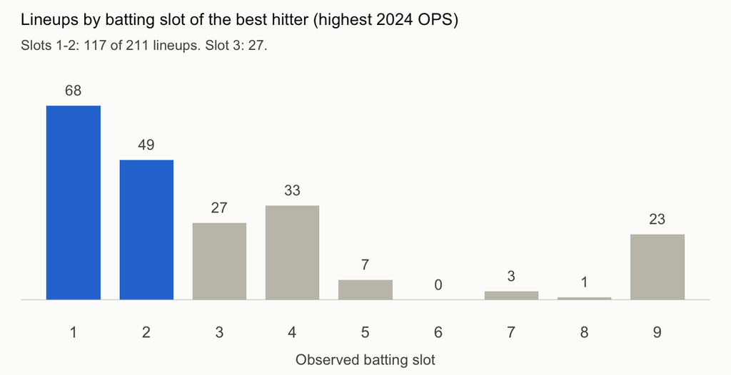

Batting slot of each lineup’s best hitter by 2024 OPS. Blue marks slots 1-2; traditional practice places this hitter third.

```r
best_ops_counts <- as.vector(table(factor(best_hitter_slots$highest_ops, levels = 1:9)))
old_par <- par(mar = c(3.6, 1, 3.2, 1), bg = "#fcfcfb")
mids <- barplot(best_ops_counts, names.arg = 1:9, col = ifelse(1:9 <= 2, "#2a78d6", "#c3c2b7"),
                border = NA, space = 0.35, axes = FALSE, ylim = c(0, max(best_ops_counts) * 1.2),
                col.axis = "#52514e", cex.names = 0.9)
abline(h = 0, col = "#c3c2b7")
text(mids, best_ops_counts, labels = best_ops_counts, pos = 3, col = "#52514e", cex = 0.85, xpd = TRUE)
mtext("Lineups by batting slot of the best hitter (highest 2024 OPS)", side = 3, line = 1.8,
      adj = 0, col = "#0b0b0b", cex = 0.95)
mtext(sprintf("Slots 1-2: %d of %d lineups. Slot 3: %d.", sum(best_ops_counts[1:2]),
              sum(best_ops_counts), best_ops_counts[3]), side = 3, line = 0.6, adj = 0, col = "#52514e", cex = 0.8)
mtext("Observed batting slot", side = 1, line = 2.3, col = "#52514e", cex = 0.85)
```

```r
par(old_par)
```

The best hitter by 2024 OPS bats first or second in **117 of 211 lineups** and third in only 27. The hitter whom the Traditional template places third bats first or second in 136 lineups. In this five-team sample, most of the 117 lineups with the best hitter in slot 1 or 2 come from four players: Shohei Ohtani leading off for the Dodgers, and Rafael Devers (Giants), Kyle Tucker (Cubs), and Willson Contreras (Cardinals) batting second. Contreras also bats fourth, the traditional cleanup slot, in many other Cardinals lineups, so the pattern is not uniform across teams. This placement is consistent with modern lineup practice, which moves the strongest hitters to the top of the order to give them more plate appearances. The scope’s Traditional rule instead fills slots 1-2 by OBP and reserves slot 3 for the best remaining OPS, so it conflicts with how these teams use their best hitters.

The 23 lineups whose best 2024 OPS bats ninth all involve Tyler Fitzgerald (Giants), whose .831 OPS came from 341 PA in 2024. Prior-season rates for partial-season players can differ from how managers judge them a year later.

### 14.4.3 Size of the Misses

For each lineup, the table measures how far the first broken rule was missed: the gap between the highest available value of the rule’s metric and the value of the batter actually placed in that slot.

```r
miss_size <- bind_rows(lapply(confirmed_lineups, function(d) {
  ok <- slot_follows_traditional(d)
  j <- which(!ok)[1]; v <- d[[rule_metric[j]]]
  tibble(first_broken_slot = j, metric = toupper(rule_metric[j]), gap = max(v[j:9]) - v[j])
}))
knitr::kable(miss_size %>% group_by(first_broken_slot, metric) %>% summarise(
  lineups = n(), median_gap = sprintf("%.3f", median(gap)), gap_at_most_010 = sum(gap <= 0.010),
  .groups = "drop"), col.names = c("First broken slot", "Metric", "Lineups", "Median gap", "Gap of .010 or less"))
```

| First broken slot | Metric | Lineups | Median gap | Gap of .010 or less |
| --- | --- | --- | --- | --- |
| 1 | OBP | 143 | 0.038 | 2 |
| 2 | OBP | 55 | 0.006 | 49 |
| 3 | OPS | 13 | 0.129 | 0 |

```r
slot2_misses <- miss_size %>% filter(first_broken_slot == 2L)
```

Two kinds of failure dominate. Most lineups break the rule at slot 1, by a wide OBP margin: the leadoff hitter is usually not the highest-OBP starter. Among the 55 lineups that first break the rule at slot 2, 49 miss by .010 OBP or less (median 0.006). An exact rule treats a .006 OBP difference, such as Freeman versus Betts, as decisive, although such differences are well within the noise of a season’s statistics.

### 14.4.4 Lineups Change From Game to Game

```r
order_keys <- vapply(confirmed_lineups, function(d) paste(d$batter_id, collapse = ","), character(1))
lineup_teams <- vapply(confirmed_lineups, function(d) d$team[1], character(1))
lineup_variation <- tibble(team = lineup_teams, order_key = order_keys) %>% group_by(team) %>%
  summarise(team_games = n(), distinct_orders = n_distinct(order_key),
            most_used_order_games = max(table(order_key)), .groups = "drop")
knitr::kable(lineup_variation, col.names = c("Team", "Team-games", "Distinct nine-player orders",
                                             "Games with the most-used order"))
```

| Team | Team-games | Distinct nine-player orders | Games with the most-used order |
| --- | --- | --- | --- |
| Angels | 13 | 10 | 2 |
| Cardinals | 56 | 35 | 6 |
| Cubs | 17 | 14 | 2 |
| Dodgers | 69 | 56 | 5 |
| Giants | 56 | 41 | 5 |

Each team uses many different orders, and no order is used in more than 6 of the sampled games. Managers adjust lineups for rest days, opposing pitchers, platoon matchups, and current form, none of which enter a rule based on prior-season OBP, OPS, and SLG.

### 14.4.5 Most-Used Lineup of Each Team Against the Template

```r
team_examples <- bind_rows(lapply(sort(unique(lineup_teams)), function(tm) {
  keys <- order_keys[lineup_teams == tm]
  top_key <- names(sort(table(keys), decreasing = TRUE))[1]
  d <- confirmed_lineups[[which(order_keys == top_key & lineup_teams == tm)[1]]]
  tibble(team = tm, games_used = sum(keys == top_key), slot = 1:9, observed = d$player,
         obp = d$obp, slg = d$slg, ops = d$ops, traditional_template = d$player[traditional_template(d)])
}))
knitr::kable(team_examples, col.names = c("Team", "Games used", "Slot", "Observed", "OBP 2024", "SLG 2024",
                                          "OPS 2024", "Traditional template"))
```

| Team | Games used | Slot | Observed | OBP 2024 | SLG 2024 | OPS 2024 | Traditional template |
| --- | --- | --- | --- | --- | --- | --- | --- |
| Angels | 2 | 1 | Jorge Soler | 0.338 | 0.442 | 0.780 | Luis Rengifo |
| Angels | 2 | 2 | Zach Neto | 0.318 | 0.443 | 0.761 | Nolan Schanuel |
| Angels | 2 | 3 | Mike Trout | 0.325 | 0.541 | 0.866 | Mike Trout |
| Angels | 2 | 4 | Taylor Ward | 0.323 | 0.426 | 0.749 | Zach Neto |
| Angels | 2 | 5 | Logan O’Hoppe | 0.303 | 0.409 | 0.712 | Jorge Soler |
| Angels | 2 | 6 | Nolan Schanuel | 0.343 | 0.362 | 0.705 | Taylor Ward |
| Angels | 2 | 7 | Luis Rengifo | 0.347 | 0.417 | 0.764 | Logan O’Hoppe |
| Angels | 2 | 8 | Jo Adell | 0.280 | 0.402 | 0.682 | Jo Adell |
| Angels | 2 | 9 | Tim Anderson | 0.237 | 0.226 | 0.463 | Tim Anderson |
| Cardinals | 6 | 1 | Brendan Donovan | 0.342 | 0.417 | 0.759 | Willson Contreras |
| Cardinals | 6 | 2 | Iván Herrera | 0.372 | 0.428 | 0.800 | Iván Herrera |
| Cardinals | 6 | 3 | Alec Burleson | 0.314 | 0.420 | 0.734 | Brendan Donovan |
| Cardinals | 6 | 4 | Willson Contreras | 0.380 | 0.468 | 0.848 | Alec Burleson |
| Cardinals | 6 | 5 | Nolan Arenado | 0.325 | 0.394 | 0.719 | Masyn Winn |
| Cardinals | 6 | 6 | Masyn Winn | 0.314 | 0.416 | 0.730 | Nolan Arenado |
| Cardinals | 6 | 7 | Jordan Walker | 0.253 | 0.366 | 0.619 | Pedro Pagés |
| Cardinals | 6 | 8 | Pedro Pagés | 0.281 | 0.376 | 0.657 | Jordan Walker |
| Cardinals | 6 | 9 | Victor Scott II | 0.219 | 0.283 | 0.502 | Victor Scott II |
| Cubs | 2 | 1 | Ian Happ | 0.341 | 0.441 | 0.782 | Kyle Tucker |
| Cubs | 2 | 2 | Kyle Tucker | 0.408 | 0.585 | 0.993 | Seiya Suzuki |
| Cubs | 2 | 3 | Seiya Suzuki | 0.366 | 0.482 | 0.848 | Ian Happ |
| Cubs | 2 | 4 | Michael Busch | 0.335 | 0.440 | 0.775 | Michael Busch |
| Cubs | 2 | 5 | Carson Kelly | 0.313 | 0.374 | 0.687 | Nico Hoerner |
| Cubs | 2 | 6 | Pete Crow-Armstrong | 0.286 | 0.384 | 0.670 | Dansby Swanson |
| Cubs | 2 | 7 | Nico Hoerner | 0.335 | 0.373 | 0.708 | Carson Kelly |
| Cubs | 2 | 8 | Dansby Swanson | 0.312 | 0.390 | 0.702 | Pete Crow-Armstrong |
| Cubs | 2 | 9 | Nicky Lopez | 0.312 | 0.294 | 0.606 | Nicky Lopez |
| Dodgers | 5 | 1 | Shohei Ohtani | 0.390 | 0.646 | 1.036 | Shohei Ohtani |
| Dodgers | 5 | 2 | Mookie Betts | 0.372 | 0.491 | 0.863 | Freddie Freeman |
| Dodgers | 5 | 3 | Freddie Freeman | 0.378 | 0.476 | 0.854 | Mookie Betts |
| Dodgers | 5 | 4 | Will Smith | 0.327 | 0.433 | 0.760 | Teoscar Hernández |
| Dodgers | 5 | 5 | Teoscar Hernández | 0.339 | 0.501 | 0.840 | Max Muncy |
| Dodgers | 5 | 6 | Max Muncy | 0.358 | 0.494 | 0.852 | Will Smith |
| Dodgers | 5 | 7 | Andy Pages | 0.305 | 0.407 | 0.712 | Michael Conforto |
| Dodgers | 5 | 8 | Michael Conforto | 0.309 | 0.450 | 0.759 | Andy Pages |
| Dodgers | 5 | 9 | Tommy Edman | 0.294 | 0.417 | 0.711 | Tommy Edman |
| Giants | 5 | 1 | Mike Yastrzemski | 0.302 | 0.437 | 0.739 | LaMonte Wade Jr. |
| Giants | 5 | 2 | Willy Adames | 0.331 | 0.462 | 0.793 | Tyler Fitzgerald |
| Giants | 5 | 3 | Jung Hoo Lee | 0.310 | 0.331 | 0.641 | Willy Adames |
| Giants | 5 | 4 | Matt Chapman | 0.328 | 0.463 | 0.791 | Heliot Ramos |
| Giants | 5 | 5 | Heliot Ramos | 0.322 | 0.469 | 0.791 | Matt Chapman |
| Giants | 5 | 6 | LaMonte Wade Jr. | 0.380 | 0.381 | 0.761 | Mike Yastrzemski |
| Giants | 5 | 7 | Wilmer Flores | 0.277 | 0.318 | 0.595 | Jung Hoo Lee |
| Giants | 5 | 8 | Patrick Bailey | 0.298 | 0.339 | 0.637 | Patrick Bailey |
| Giants | 5 | 9 | Tyler Fitzgerald | 0.334 | 0.497 | 0.831 | Wilmer Flores |

The examples show the same pattern. The template moves the highest-OBP hitter to the top even when the team bats him lower, for example LaMonte Wade Jr. (Giants, .380 OBP, sixth) and Willson Contreras (Cardinals, .380 OBP, fourth). It also moves the best OPS hitter out of the slot the team chose for him, for example Kyle Tucker (Cubs) from second to first.

## 14.5 Conclusion for Scope Review

1. Applied exactly as written, the scope’s rules classify no 2025 half-inning as Traditional and one game as OPS-ranked. The two-group comparison planned in the scope cannot be carried out with this definition. This holds under both readings of Strategy B, with 2025 metrics, and without the PA threshold.
2. The cause is the definition, not data quality. The input checks earlier in this document pass, and the observed lineups are verified against official MLB records.
3. Strategies A and B are construction rules: given nine hitters and their metrics, they produce one specific order each. That design suits a simulation that bats the same nine hitters in both orders, which is also the scope’s stated objective of testing whether rearranging the same hitters improves expected production. As a description of how managers actually set lineups, the rules almost never hold.
4. Moving forward requires a scope decision by the project team: either compare A and B by simulation, or redefine the observational groups with a looser rule fixed before any runs are examined. A looser rule would change the research question and must be reported as such. Neither option is implemented in this version.